# Unified Analysis — LLM Phrasal Compositionality

Zachary Houghton

2026-04-17

```r
library(tidyverse)
library(brms)
library(mgcv)
library(tidybayes)
library(patchwork)
library(viridis)
```

```r
library(plotly)
library(jsonlite)
```

# Configuration

This document produces results for all three model families (OLMo, BabyLM, Whisper) in a single knit.

Fitted model objects (brms and bam) are cached in `../model_cache/{family}/` which is gitignored so large files are not uploaded to GitHub.

```r
OLMO_CACHE_DIR   = "../model_cache/olmo"
BLM_CACHE_DIR    = "../model_cache/babylm"
WH_CACHE_DIR     = "../model_cache/whisper"

dir.create(OLMO_CACHE_DIR, recursive = TRUE, showWarnings = FALSE)
dir.create(BLM_CACHE_DIR,  recursive = TRUE, showWarnings = FALSE)
dir.create(WH_CACHE_DIR,   recursive = TRUE, showWarnings = FALSE)

priors = c(prior(normal(0, 1), class = 'b'))

# OLMo cache helpers
olmo_rds_path  = function(name) file.path(OLMO_CACHE_DIR, paste0(name, ".rds"))
olmo_brms_path = function(name) file.path(OLMO_CACHE_DIR, name)
olmo_cache_bam = function(name, expr_fn) {
  p = olmo_rds_path(name)
  if (file.exists(p)) readRDS(p) else { m = expr_fn(); saveRDS(m, p); m }
}

# BabyLM cache helpers
blm_rds_path  = function(name) file.path(BLM_CACHE_DIR, paste0(name, ".rds"))
blm_brms_path = function(name) file.path(BLM_CACHE_DIR, name)
blm_cache_bam = function(name, expr_fn) {
  p = blm_rds_path(name)
  if (file.exists(p)) readRDS(p) else { m = expr_fn(); saveRDS(m, p); m }
}

# Whisper cache helpers
wh_rds_path  = function(name) file.path(WH_CACHE_DIR, paste0(name, ".rds"))
wh_brms_path = function(name) file.path(WH_CACHE_DIR, name)
wh_cache_bam = function(name, expr_fn) {
  p = wh_rds_path(name)
  if (file.exists(p)) readRDS(p) else { m = expr_fn(); saveRDS(m, p); m }
}
```

# Data loading

```r
olmo_indep = read_csv('../Data/olmo-3-7b/Data_up/all_layers_results.csv') %>%
  mutate(log_freq = log(frequency), log_ftp = log(ftp / (1 - ftp)), verb_up = factor(verb_up)) %>%
  filter(!is.na(ftp), is.finite(log_ftp))
olmo_sub = read_csv('../Data/olmo-3-7b/Data_upsubword/all_layers_results.csv') %>%
  mutate(log_freq = log(frequency), log_ftp = log(ftp / (1 - ftp)), verb_up = factor(verb_up)) %>%
  filter(!is.na(ftp), is.finite(log_ftp))
OLMO_FINAL_LAYER = 31
OLMO_N_LAYERS    = 32

olmo_indep_final = olmo_indep %>% filter(layer == OLMO_FINAL_LAYER)
olmo_sub_final   = olmo_sub   %>% filter(layer == OLMO_FINAL_LAYER)
olmo_indep_first = olmo_indep %>% filter(layer == 0)
olmo_sub_first   = olmo_sub   %>% filter(layer == 0)
```

```r
BLM_FINAL_LAYER_MAP = list("opt-125m" = 11L, "opt-350m" = 23L, "opt-1.3b" = 23L)

load_babylm_model = function(tag) {
  ui = read_csv(paste0('../Data/babylm/', tag, '/Data_up/all_layers_results.csv')) %>%
    mutate(model = tag, log_freq = log(frequency), log_ftp = log(ftp / (1 - ftp)), verb_up = factor(verb_up)) %>%
    filter(!is.na(ftp), is.finite(log_ftp))
  us = read_csv(paste0('../Data/babylm/', tag, '/Data_upsubword/all_layers_results.csv')) %>%
    mutate(model = tag, log_freq = log(frequency), log_ftp = log(ftp / (1 - ftp)), verb_up = factor(verb_up)) %>%
    filter(!is.na(ftp), is.finite(log_ftp))
  list(ui = ui, us = us)
}

blm_raw = lapply(c("opt-125m", "opt-350m", "opt-1.3b"), load_babylm_model)
```

```r
names(blm_raw) = c("opt-125m", "opt-350m", "opt-1.3b")

blm_indep = map_dfr(blm_raw, "ui") %>%
  mutate(model = factor(model, levels = c("opt-125m", "opt-350m", "opt-1.3b"))) %>%
  group_by(model) %>% mutate(layer_norm = layer / max(layer)) %>% ungroup()

blm_sub = map_dfr(blm_raw, "us") %>%
  mutate(model = factor(model, levels = c("opt-125m", "opt-350m", "opt-1.3b"))) %>%
  group_by(model) %>% mutate(layer_norm = layer / max(layer)) %>% ungroup()

blm_indep_final = blm_indep %>%
  group_by(model) %>%
  filter(layer == BLM_FINAL_LAYER_MAP[[as.character(model[1])]]) %>% ungroup()

blm_sub_final = blm_sub %>%
  group_by(model) %>%
  filter(layer == BLM_FINAL_LAYER_MAP[[as.character(model[1])]]) %>% ungroup()

blm_indep_first = blm_indep %>% filter(layer == 0)
blm_sub_first   = blm_sub   %>% filter(layer == 0)
```

```r
# FTP values come from C4 via the shared ftp_lookup.csv (same source as OLMo)
ftp_lookup = read_csv('../Data/ftp_lookup.csv')  # columns: verb_up, ftp
load_whisper_component = function(path, comp) {
  read_csv(path) %>%
    select(-any_of("ftp")) %>%          # drop any pre-existing ftp column
    mutate(component = comp, log_freq = log(frequency),
           verb_up_chr = as.character(verb_up)) %>%
    left_join(ftp_lookup, by = c("verb_up_chr" = "verb_up")) %>%
    filter(!is.na(ftp)) %>%
    mutate(log_ftp = log(ftp / (1 - ftp)), verb_up = factor(verb_up_chr)) %>%
    filter(is.finite(log_ftp)) %>%
    select(-verb_up_chr)
}

encoder = load_whisper_component('../Data/whisper/encoder/all_layers_results.csv', "encoder")
decoder = load_whisper_component('../Data/whisper/decoder/all_layers_results.csv', "decoder")
whisper_all = bind_rows(encoder, decoder) %>%
  mutate(component = factor(component, levels = c("encoder", "decoder")))

WH_FINAL_LAYER = 11
WH_N_LAYERS    = 12

whisper_final = whisper_all %>% filter(layer == WH_FINAL_LAYER)
whisper_first = whisper_all %>% filter(layer == 0)
```

# Predictor Definitions

## Frequency

Corpus frequency is the raw count of each V+up type (e.g. *pick up*, *set up*) in the training corpus of each model. Because frequency distributions are highly right-skewed — a small number of very common types account for the vast majority of tokens — we log-transform before entering it as a predictor:

$$\text{log-frequency} = \log\bigl(\text{count}(V\text{+up})\bigr)$$

Log-frequency is used as a continuous predictor throughout all models.

> **Corpus note.** OLMo and Whisper use C4 corpus statistics (frequency and FTP), since both models were trained on or evaluated against web text of that scale. BabyLM uses its own training corpus statistics (`babylm_corpus_stats.pkl`), since its models were trained on a qualitatively different, much smaller dataset (~100M words). Using corpus-matched statistics for each model ensures that the predictors reflect the distributional environment the model actually learned from.

## Predictability: Forward Transitional Probability and its log-odds

**Step 1 — Define FTP.** The Forward Transitional Probability of a V+up type measures how strongly the verb *predicts* the following particle. Formally, it is the conditional probability of “up” given the verb:

$$\text{FTP}(V\text{+up}) = P(\text{"up"} \mid V) = \frac{\text{count}(V\text{+up})}{\text{count}(V)}$$

where count$(V)$ is the total corpus frequency of the verb in any context. A high FTP (e.g. *end up*: FTP ≈ 0.09) means “up” is a relatively likely continuation of that verb; a low FTP means the verb occurs in many contexts and “up” is just one of them.

**Step 2 — Convert to odds.** FTP is a probability bounded in $[0, 1]$, which makes it poorly suited for use as a linear predictor. We first convert to odds — the ratio of “up follows V” to “up does not follow V”:

$$\text{odds}(V\text{+up}) = \frac{P(\text{"up"} \mid V)}{1 - P(\text{"up"} \mid V)} = \frac{\text{FTP}}{1 - \text{FTP}}$$

Substituting the count-based definition of FTP into both numerator and denominator:

$$= \frac{\dfrac{\text{count}(V\text{+up})}{\text{count}(V)}}{\ 1 - \dfrac{\text{count}(V\text{+up})}{\text{count}(V)}\ } = \frac{\dfrac{\text{count}(V\text{+up})}{\text{count}(V)}}{\dfrac{\text{count}(V) - \text{count}(V\text{+up})}{\text{count}(V)}}$$

The count$(V)$ terms cancel:

$$= \frac{\text{count}(V\text{+up})}{\text{count}(V) - \text{count}(V\text{+up})}$$

This is the ratio of *V+up* occurrences to occurrences of V that are *not* followed by “up” — a natural measure of how much “up” dominates the verb’s distributional context.

**Step 3 — Take the log.** Taking the logarithm converts the odds to a symmetric, unbounded scale suitable for linear modelling:

$$\text{log-odds}(V\text{+up}) = \log\!\left(\frac{\text{count}(V\text{+up})}{\text{count}(V) - \text{count}(V\text{+up})}\right)$$

Because we derived this from FTP = count$(V\text{+up})$ / count$(V)$, this expression is algebraically identical to the logit of FTP:

$$= \log\!\left(\frac{\text{FTP}}{1 - \text{FTP}}\right) = \operatorname{logit}(\text{FTP})$$

In R this is computed as `log(ftp / (1 - ftp))` and used as the predictability predictor in all models.

# Item Statistics

OLMo and Whisper use C4 corpus frequency and FTP (from `ftp_lookup.csv`). BabyLM uses its own training corpus statistics (`babylm_corpus_stats.pkl`), since its models were trained on a qualitatively different, much smaller dataset (~100M words).

## Build item tables

```r
olmo_items = olmo_indep %>%
  filter(layer == 0) %>%
  group_by(verb_up) %>%
  summarise(frequency = first(frequency), ftp = first(ftp),
            log_freq = first(log_freq), log_ftp = first(log_ftp),
            .groups = "drop")
```

```r
# Use opt-125m as the representative model for item-level statistics
blm_items = blm_indep %>%
  filter(layer == 0, model == "opt-125m") %>%
  group_by(verb_up) %>%
  summarise(frequency = first(frequency), ftp = first(ftp),
            log_freq = first(log_freq), log_ftp = first(log_ftp),
            .groups = "drop")
```

```r
whisper_items = whisper_all %>%
  filter(layer == 0, component == "encoder") %>%
  group_by(verb_up) %>%
  summarise(frequency = first(frequency), ftp = first(ftp),
            log_freq = first(log_freq), log_ftp = first(log_ftp),
            .groups = "drop")
```

## Summary tables

```r
make_item_summary = function(items, label) {
  tibble(
    Source              = label,
    `N items`           = nrow(items),
    `Median freq`       = as.integer(median(items$frequency)),
    `Freq range`        = sprintf("%d – %d", min(items$frequency), max(items$frequency)),
    `IQR freq`          = sprintf("%d – %d",
                            as.integer(quantile(items$frequency, 0.25)),
                            as.integer(quantile(items$frequency, 0.75))),
    `Median FTP`        = round(median(items$ftp), 4),
    `FTP range`         = sprintf("%.4f – %.4f", min(items$ftp), max(items$ftp)),
    `IQR FTP`           = sprintf("%.4f – %.4f",
                            quantile(items$ftp, 0.25),
                            quantile(items$ftp, 0.75)),
    `Med log(freq)`     = round(median(items$log_freq), 2),
    `Med logit(FTP)`    = round(median(items$log_ftp),  2),
    `ρ(log freq, logit FTP)` = round(cor(items$log_freq, items$log_ftp,
                                          method = "spearman"), 3)
  )
}

bind_rows(
  make_item_summary(olmo_items,    "OLMo-3 7B"),
  make_item_summary(blm_items,     "BabyLM (opt-125m)"),
  make_item_summary(whisper_items, "Whisper-small")
) %>%
  knitr::kable(
    caption = "Item-level statistics across model families",
    align   = c("l", "r", "r", "r", "r", "r", "r", "r", "r", "r", "r")
  )
```

Item-level statistics across model families

| Source | N items | Median freq | Freq range | IQR freq | Median FTP | FTP range | IQR FTP | Med log(freq) | Med logit(FTP) | ρ(log freq, logit FTP) |
| --- | --- | --- | --- | --- | --- | --- | --- | --- | --- | --- |
| OLMo-3 7B | 3927 | 92 | 20 – 390086 | 39 – 387 | 0.0046 | 0.0000 – 0.9800 | 0.0010 – 0.0256 | 4.52 | -5.38 | 0.441 |
| BabyLM (opt-125m) | 1039 | 920 | 20 – 390086 | 240 – 3441 | 0.0325 | 0.0000 – 0.8800 | 0.0102 – 0.0896 | 6.82 | -3.40 | 0.061 |
| Whisper-small | 1397 | 683 | 20 – 390086 | 209 – 2353 | 0.0172 | 0.0000 – 0.9800 | 0.0050 – 0.0596 | 6.53 | -4.05 | 0.374 |

## Top / bottom 5 by frequency and predictability

```r
make_extremes_table = function(items, label) {
  bind_rows(
    items %>% arrange(desc(frequency)) %>% slice(1:5) %>%
      mutate(Group = "Most frequent"),
    items %>% arrange(frequency)       %>% slice(1:5) %>%
      mutate(Group = "Least frequent"),
    items %>% arrange(desc(ftp))       %>% slice(1:5) %>%
      mutate(Group = "Most predictable (highest FTP)"),
    items %>% arrange(ftp)             %>% slice(1:5) %>%
      mutate(Group = "Least predictable (lowest FTP)")
  ) %>%
    select(Group, `V+up` = verb_up, Frequency = frequency, FTP = ftp) %>%
    knitr::kable(
      caption = paste0(label, ": top and bottom 5 items by frequency and predictability"),
      digits  = 4
    )
}

make_extremes_table(olmo_items,    "OLMo-3 7B")
```

OLMo-3 7B: top and bottom 5 items by frequency and predictability

| Group | V+up | Frequency | FTP |
| --- | --- | --- | --- |
| Most frequent | set up | 390086 | 0.1643 |
| Most frequent | end up | 185436 | 0.0898 |
| Most frequent | pick up | 178378 | 0.3746 |
| Most frequent | sign up | 171197 | 0.3103 |
| Most frequent | come up | 162149 | 0.0687 |
| Least frequent | accommodation up | 20 | 0.0010 |
| Least frequent | accrued up | 20 | 0.0013 |
| Least frequent | amended up | 20 | 0.0006 |
| Least frequent | assess up | 20 | 0.0001 |
| Least frequent | attending up | 20 | 0.0001 |
| Most predictable (highest FTP) | cozying up | 638 | 0.9800 |
| Most predictable (highest FTP) | cooped up | 1287 | 0.9697 |
| Most predictable (highest FTP) | souped up | 304 | 0.9677 |
| Most predictable (highest FTP) | ponied up | 220 | 0.9500 |
| Most predictable (highest FTP) | fessed up | 149 | 0.9444 |
| Least predictable (lowest FTP) | ve up | 46 | 0.0000 |
| Least predictable (lowest FTP) | determine up | 40 | 0.0000 |
| Least predictable (lowest FTP) | trying up | 28 | 0.0000 |
| Least predictable (lowest FTP) | explain up | 32 | 0.0000 |
| Least predictable (lowest FTP) | chosen up | 25 | 0.0001 |

```r
make_extremes_table(blm_items,     "BabyLM (opt-125m)")
```

BabyLM (opt-125m): top and bottom 5 items by frequency and predictability

| Group | V+up | Frequency | FTP |
| --- | --- | --- | --- |
| Most frequent | set up | 390086 | 0.1160 |
| Most frequent | end up | 185436 | 0.0476 |
| Most frequent | pick up | 178378 | 0.2857 |
| Most frequent | sign up | 171197 | 0.0148 |
| Most frequent | come up | 162149 | 0.0225 |
| Least frequent | foot up | 20 | 0.0011 |
| Least frequent | lying up | 20 | 0.0015 |
| Least frequent | flamed up | 21 | 0.1829 |
| Least frequent | galloping up | 21 | 0.0506 |
| Least frequent | leans up | 21 | 0.0044 |
| Most predictable (highest FTP) | fess up | 415 | 0.8800 |
| Most predictable (highest FTP) | cooped up | 1287 | 0.8750 |
| Most predictable (highest FTP) | picks up | 14276 | 0.8046 |
| Most predictable (highest FTP) | woken up | 3702 | 0.7941 |
| Most predictable (highest FTP) | dolled up | 747 | 0.7647 |
| Least predictable (lowest FTP) | be up | 79 | 0.0000 |
| Least predictable (lowest FTP) | like up | 93 | 0.0000 |
| Least predictable (lowest FTP) | said up | 254 | 0.0000 |
| Least predictable (lowest FTP) | know up | 495 | 0.0001 |
| Least predictable (lowest FTP) | s up | 1089 | 0.0001 |

```r
make_extremes_table(whisper_items, "Whisper-small")
```

Whisper-small: top and bottom 5 items by frequency and predictability

| Group | V+up | Frequency | FTP |
| --- | --- | --- | --- |
| Most frequent | set up | 390086 | 0.1643 |
| Most frequent | end up | 185436 | 0.0898 |
| Most frequent | pick up | 178378 | 0.3746 |
| Most frequent | sign up | 171197 | 0.3103 |
| Most frequent | come up | 162149 | 0.0687 |
| Least frequent | blazing up | 20 | 0.0039 |
| Least frequent | brimmed up | 20 | 0.0227 |
| Least frequent | heave up | 20 | 0.0064 |
| Least frequent | rattled up | 20 | 0.0028 |
| Least frequent | retained up | 20 | 0.0003 |
| Most predictable (highest FTP) | cozying up | 638 | 0.9800 |
| Most predictable (highest FTP) | cooped up | 1287 | 0.9697 |
| Most predictable (highest FTP) | souped up | 304 | 0.9677 |
| Most predictable (highest FTP) | fessed up | 149 | 0.9444 |
| Most predictable (highest FTP) | beefing up | 923 | 0.9250 |
| Least predictable (lowest FTP) | ve up | 46 | 0.0000 |
| Least predictable (lowest FTP) | want up | 199 | 0.0001 |
| Least predictable (lowest FTP) | notice up | 21 | 0.0001 |
| Least predictable (lowest FTP) | google up | 30 | 0.0001 |
| Least predictable (lowest FTP) | like up | 93 | 0.0001 |

## Item distribution plots

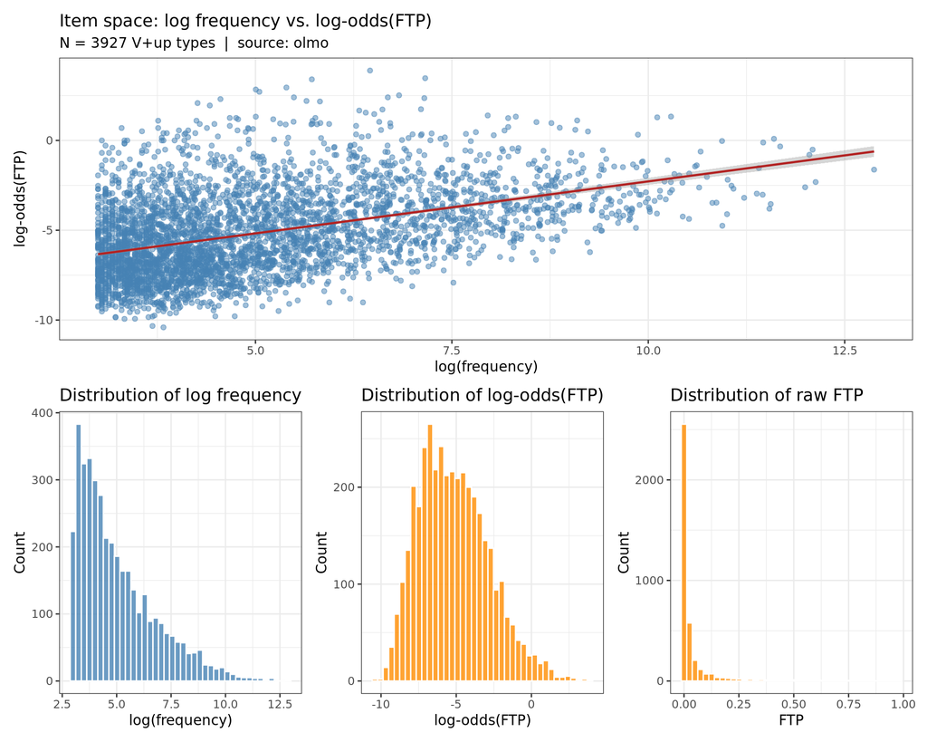

```r
plot_item_space = function(items, source_label) {
  p_scatter = ggplot(items, aes(x = log_freq, y = log_ftp, label = verb_up)) +
    geom_point(alpha = 0.5, size = 1.5, colour = "steelblue") +
    geom_smooth(method = "lm", colour = "firebrick", linewidth = 0.8, se = TRUE) +
    labs(x = "log(frequency)", y = "log-odds(FTP)",
         title = "Item space: log frequency vs. log-odds(FTP)",
         subtitle = sprintf("N = %d V+up types  |  source: %s", nrow(items), source_label)) +
    theme_bw()

  p_freq_hist = ggplot(items, aes(x = log_freq)) +
    geom_histogram(bins = 40, fill = "steelblue", colour = "white", alpha = 0.8) +
    labs(x = "log(frequency)", y = "Count", title = "Distribution of log frequency") +
    theme_bw()

  p_ftp_hist = ggplot(items, aes(x = log_ftp)) +
    geom_histogram(bins = 40, fill = "darkorange", colour = "white", alpha = 0.8) +
    labs(x = "log-odds(FTP)", y = "Count", title = "Distribution of log-odds(FTP)") +
    theme_bw()

  p_ftp_raw = ggplot(items, aes(x = ftp)) +
    geom_histogram(bins = 40, fill = "darkorange", colour = "white", alpha = 0.8) +
    labs(x = "FTP", y = "Count", title = "Distribution of raw FTP") +
    theme_bw()

  (p_scatter) / (p_freq_hist | p_ftp_hist | p_ftp_raw)
}

plot_item_space(olmo_items,    "olmo")
```

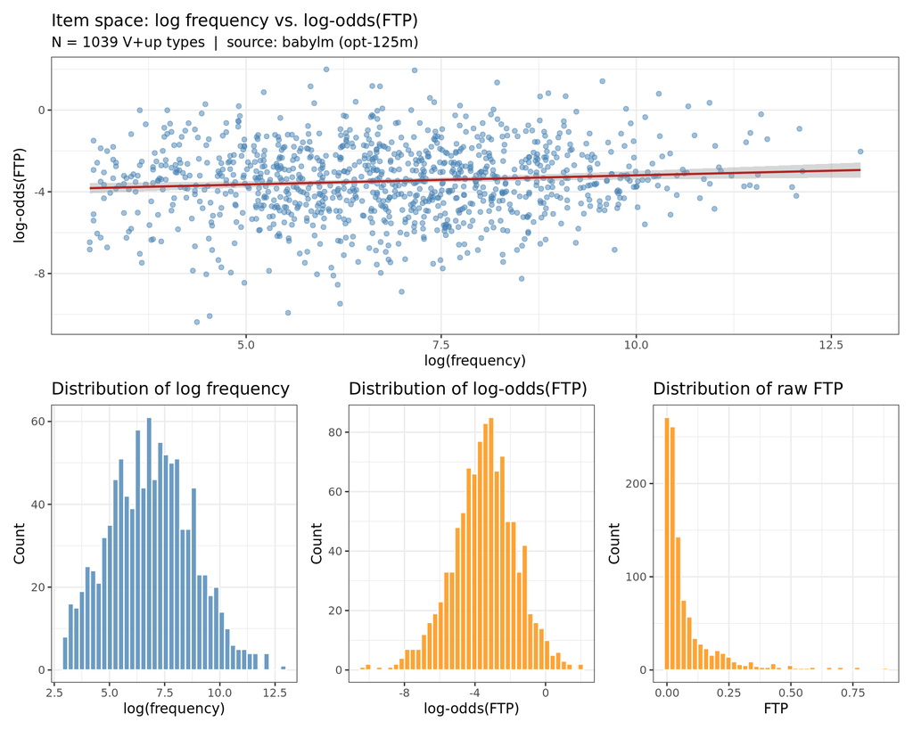

```r
plot_item_space(blm_items,     "babylm (opt-125m)")
```

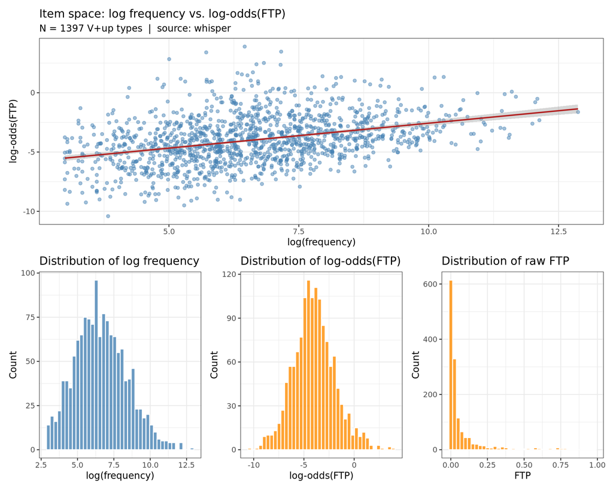

```r
plot_item_space(whisper_items, "whisper")
```

# OLMo-3 7B Analysis

## Plot helper functions (OLMo)

```r
plot_final_layer = function(model, data, title) {
  # Population-level predictions (random effects marginalized)
  log_freq_seq = seq(min(data$log_freq), max(data$log_freq), length.out = 100)
  newdata = data.frame(log_freq = log_freq_seq, verb_up = NA)
  epred = add_epred_draws(newdata, model, re_formula = NA, ndraws = 500)

  # Per-verb_up mean logit (one point per type, averaging over sentences)
  points_df = data %>%
    group_by(verb_up, log_freq) %>%
    summarise(mean_logit = mean(logit), .groups = "drop")

  epred %>%
    ggplot(aes(x = log_freq, y = .epred)) +
    stat_lineribbon(.width = c(0.95, 0.80, 0.50), alpha = 0.35) +
    scale_fill_manual(
      values = c("0.95" = "#b3cde3", "0.80" = "#6497b1", "0.50" = "#005b96"),
      labels = c("95%", "80%", "50%")
    ) +
    geom_point(data = points_df, aes(x = log_freq, y = mean_logit),
               color = "gray30", size = 1.5, alpha = 0.6, inherit.aes = FALSE) +
    labs(title = title, x = "log(frequency)", y = "Predicted logit",
         subtitle = "Line: population-level effect (random intercepts marginalized)",
         fill = "Credible interval") +
    theme_minimal(base_size = 13) +
    theme(plot.title = element_text(size = 11, face = "bold", margin = margin(b = 8)),
          panel.grid.minor = element_blank(), legend.position = "bottom",
          legend.key.size = unit(0.5, "cm"))
}

plot_bam_single_layer = function(model, data, title) {
  log_freq_seq = seq(min(data$log_freq), max(data$log_freq), length.out = 200)
  newdata = data.frame(log_freq = log_freq_seq, verb_up = data$verb_up[1])
  preds = predict(model, newdata = newdata, se.fit = TRUE, exclude = 's(verb_up)')
  newdata = newdata %>%
    mutate(fit = preds$fit, se = preds$se.fit,
           lo95 = fit - 1.96 * se, hi95 = fit + 1.96 * se,
           lo80 = fit - 1.28 * se, hi80 = fit + 1.28 * se,
           lo50 = fit - 0.67 * se, hi50 = fit + 0.67 * se)
  ggplot(newdata, aes(x = log_freq, y = fit)) +
    geom_ribbon(aes(ymin = lo95, ymax = hi95), fill = "#b3cde3", alpha = 0.5) +
    geom_ribbon(aes(ymin = lo80, ymax = hi80), fill = "#6497b1", alpha = 0.5) +
    geom_ribbon(aes(ymin = lo50, ymax = hi50), fill = "#005b96", alpha = 0.5) +
    geom_line(linewidth = 1, color = "#003366") +
    stat_summary(data = data, aes(x = log_freq, y = logit),
                 fun = mean, geom = "point", color = "gray30", size = 1.5, alpha = 0.6) +
    labs(title = title, x = "log(frequency)", y = "Predicted logit",
         subtitle = "Ribbons: 50%, 80%, 95% CI  |  bam() s(log_freq)") +
    theme_minimal(base_size = 13) +
    theme(plot.title = element_text(size = 11, face = "bold", margin = margin(b = 4)),
          plot.subtitle = element_text(size = 9, color = "gray50"),
          panel.grid.minor = element_blank())
}

plot_brms_vs_bam = function(brms_model, bam_model, data, title) {
  log_freq_seq = seq(min(data$log_freq), max(data$log_freq), length.out = 200)
  newdata_brms = data.frame(log_freq = log_freq_seq, verb_up = NA)
  epred = add_epred_draws(newdata_brms, brms_model, re_formula = NA, ndraws = 500)
  brms_ribbon = epred %>% group_by(log_freq) %>%
    summarise(fit = mean(.epred), lo95 = quantile(.epred, 0.025),
              hi95 = quantile(.epred, 0.975), .groups = "drop")
  newdata_bam = data.frame(log_freq = log_freq_seq, verb_up = data$verb_up[1])
  preds_bam   = predict(bam_model, newdata = newdata_bam, se.fit = TRUE, exclude = 's(verb_up)')
  bam_ribbon  = data.frame(log_freq = log_freq_seq, fit = preds_bam$fit,
                            lo95 = preds_bam$fit - 1.96 * preds_bam$se.fit,
                            hi95 = preds_bam$fit + 1.96 * preds_bam$se.fit)
  raw = data %>% group_by(log_freq) %>% summarise(logit = mean(logit), .groups = "drop")
  ggplot() +
    geom_ribbon(data = brms_ribbon, aes(x = log_freq, ymin = lo95, ymax = hi95,
                                         fill = "brms (linear)"), alpha = 0.25) +
    geom_line(data = brms_ribbon, aes(x = log_freq, y = fit, color = "brms (linear)"),
              linewidth = 1) +
    geom_ribbon(data = bam_ribbon, aes(x = log_freq, ymin = lo95, ymax = hi95,
                                        fill = "bam (non-linear)"), alpha = 0.25) +
    geom_line(data = bam_ribbon, aes(x = log_freq, y = fit, color = "bam (non-linear)"),
              linewidth = 1, linetype = "dashed") +
    geom_point(data = raw, aes(x = log_freq, y = logit), color = "gray30", size = 1.2, alpha = 0.5) +
    scale_fill_manual(values  = c("brms (linear)" = "#e07b54", "bam (non-linear)" = "#005b96")) +
    scale_color_manual(values = c("brms (linear)" = "#e07b54", "bam (non-linear)" = "#005b96")) +
    labs(title = title, x = "log(frequency)", y = "Predicted logit",
         fill = "Model", color = "Model", subtitle = "Points = per-freq mean logit") +
    theme_minimal(base_size = 13) +
    theme(plot.title = element_text(size = 11, face = "bold"),
          plot.subtitle = element_text(size = 9, color = "gray50"),
          panel.grid.minor = element_blank(), legend.position = "bottom")
}

plot_freq_by_layer_mgcv = function(model, data, title, n_layers = 32) {
  layer_seq    = 0:(n_layers - 1)
  log_freq_seq = seq(min(data$log_freq), max(data$log_freq), length.out = 50)
  log_freq_lo  = quantile(data$log_freq, 0.1)
  log_freq_hi  = quantile(data$log_freq, 0.9)
  newdata_sp = expand.grid(layer = layer_seq, log_freq = log_freq_seq) %>%
    mutate(verb_up = data$verb_up[1])
  preds_sp = predict(model, newdata = newdata_sp, se.fit = TRUE, exclude = 's(verb_up)')
  newdata_sp = newdata_sp %>%
    mutate(fit = preds_sp$fit, se = preds_sp$se.fit,
           lo95 = fit - 1.96 * se, hi95 = fit + 1.96 * se)
  p_spaghetti = newdata_sp %>%
    ggplot(aes(x = log_freq, y = fit, color = layer, group = factor(layer))) +
    geom_line(linewidth = 0.7, alpha = 0.8) +
    scale_color_viridis_c(option = "plasma", name = "Layer") +
    labs(title = paste0(title, ": effect of log(freq) by layer"),
         x = "log(frequency)", y = "Predicted logit") +
    theme_minimal()
  p_heatmap = newdata_sp %>%
    ggplot(aes(x = layer, y = log_freq, fill = fit)) +
    geom_tile() +
    scale_fill_viridis_c(option = "magma", name = "Predicted\nlogit") +
    labs(title = paste0(title, ": predicted logit surface"),
         x = "Layer", y = "log(frequency)") +
    theme_minimal()
  newdata_diff = expand.grid(layer = layer_seq, freq_level = c("low", "high")) %>%
    mutate(log_freq = ifelse(freq_level == "low", log_freq_lo, log_freq_hi),
           verb_up  = data$verb_up[1])
  preds_diff = predict(model, newdata = newdata_diff, se.fit = TRUE, exclude = 's(verb_up)')
  newdata_diff = newdata_diff %>% mutate(fit = preds_diff$fit, se = preds_diff$se.fit)
  p_diff = newdata_diff %>%
    select(layer, freq_level, fit, se) %>%
    pivot_wider(names_from = freq_level, values_from = c(fit, se)) %>%
    mutate(diff = fit_high - fit_low, se_diff = sqrt(se_high^2 + se_low^2),
           lo95 = diff - 1.96 * se_diff, hi95 = diff + 1.96 * se_diff,
           lo80 = diff - 1.28 * se_diff, hi80 = diff + 1.28 * se_diff) %>%
    ggplot(aes(x = layer, y = diff)) +
    geom_ribbon(aes(ymin = lo95, ymax = hi95), fill = "steelblue", alpha = 0.2) +
    geom_ribbon(aes(ymin = lo80, ymax = hi80), fill = "steelblue", alpha = 0.3) +
    geom_line(linewidth = 1, color = "steelblue4") +
    geom_hline(yintercept = 0, linetype = "dashed", color = "gray40") +
    labs(title = paste0(title, ": frequency effect (high − low) across layers"),
         x = "Layer", y = "Difference in predicted logit (90th − 10th pct freq)") +
    theme_minimal()
  fit_matrix = newdata_sp %>% select(layer, log_freq, fit) %>%
    pivot_wider(names_from = layer, values_from = fit) %>%
    arrange(log_freq) %>% select(-log_freq) %>% as.matrix()
  p_3d = plot_ly(x = ~layer_seq, y = ~log_freq_seq, z = ~fit_matrix,
                 type = "surface", colorscale = "Viridis", showscale = TRUE) %>%
    layout(title = paste0(title, ": 3D predicted logit surface"),
           scene = list(xaxis = list(title = "Layer"),
                        yaxis = list(title = "log(frequency)"),
                        zaxis = list(title = "Predicted logit")))
  list(spaghetti = p_spaghetti, heatmap = p_heatmap, diff = p_diff, surface3d = p_3d)
}

plot_ftp_by_layer_mgcv = function(model, data, title, n_layers = 32) {
  layer_seq = 0:(n_layers - 1)
  ftp_seq   = seq(min(data$log_ftp, na.rm = TRUE), max(data$log_ftp, na.rm = TRUE), length.out = 50)
  ftp_lo    = quantile(data$log_ftp, 0.1, na.rm = TRUE)
  ftp_hi    = quantile(data$log_ftp, 0.9, na.rm = TRUE)
  newdata_sp = expand.grid(layer = layer_seq, log_ftp = ftp_seq) %>%
    mutate(verb_up = data$verb_up[1])
  preds = predict(model, newdata = newdata_sp, se.fit = TRUE, exclude = 's(verb_up)')
  newdata_sp$fit = preds$fit
  p_spaghetti = newdata_sp %>%
    ggplot(aes(x = log_ftp, y = fit, color = layer, group = factor(layer))) +
    geom_line(linewidth = 0.7, alpha = 0.8) +
    scale_color_viridis_c(option = "plasma", name = "Layer") +
    labs(title = paste0(title, ": FTP effect by layer"), x = "log(FTP)", y = "Predicted logit") +
    theme_minimal()
  p_heatmap = newdata_sp %>%
    ggplot(aes(x = layer, y = log_ftp, fill = fit)) + geom_tile() +
    scale_fill_viridis_c(option = "magma", name = "Predicted\nlogit") +
    labs(title = paste0(title, ": predicted logit surface (FTP)"),
         x = "Layer", y = "log(FTP)") + theme_minimal()
  newdata_diff = expand.grid(layer = layer_seq, ftp_level = c("low", "high")) %>%
    mutate(log_ftp = ifelse(ftp_level == "low", ftp_lo, ftp_hi), verb_up = data$verb_up[1])
  preds_diff = predict(model, newdata = newdata_diff, se.fit = TRUE, exclude = 's(verb_up)')
  newdata_diff$fit = preds_diff$fit; newdata_diff$se = preds_diff$se.fit
  p_diff = newdata_diff %>%
    select(layer, ftp_level, fit, se) %>%
    pivot_wider(names_from = ftp_level, values_from = c(fit, se)) %>%
    mutate(diff = fit_high - fit_low, se_diff = sqrt(se_high^2 + se_low^2),
           lo95 = diff - 1.96 * se_diff, hi95 = diff + 1.96 * se_diff,
           lo80 = diff - 1.28 * se_diff, hi80 = diff + 1.28 * se_diff) %>%
    ggplot(aes(x = layer, y = diff)) +
    geom_ribbon(aes(ymin = lo95, ymax = hi95), fill = "darkorange", alpha = 0.2) +
    geom_ribbon(aes(ymin = lo80, ymax = hi80), fill = "darkorange", alpha = 0.3) +
    geom_line(linewidth = 1, color = "darkorange4") +
    geom_hline(yintercept = 0, linetype = "dashed", color = "gray40") +
    labs(title = paste0(title, ": FTP effect (high − low) across layers"),
         x = "Layer", y = "Difference in predicted logit (90th − 10th pct FTP)") +
    theme_minimal()
  list(spaghetti = p_spaghetti, heatmap = p_heatmap, diff = p_diff)
}

plot_joint_surface = function(model, data, title) {
  log_freq_seq = seq(min(data$log_freq, na.rm = TRUE), max(data$log_freq, na.rm = TRUE), length.out = 50)
  log_ftp_seq  = seq(min(data$log_ftp,  na.rm = TRUE), max(data$log_ftp,  na.rm = TRUE), length.out = 50)
  newdata = expand.grid(log_freq = log_freq_seq, log_ftp = log_ftp_seq) %>%
    mutate(verb_up = data$verb_up[1])
  preds = predict(model, newdata = newdata, se.fit = FALSE, exclude = 's(verb_up)')
  newdata$fit = preds
  p_heat = newdata %>%
    ggplot(aes(x = log_freq, y = log_ftp, fill = fit)) + geom_tile() +
    scale_fill_viridis_c(option = "magma", name = "Predicted\nlogit") +
    labs(title = title, x = "log(frequency)", y = "log(FTP)") + theme_minimal()
  fit_matrix = newdata %>% select(log_freq, log_ftp, fit) %>%
    pivot_wider(names_from = log_freq, values_from = fit) %>%
    select(-log_ftp) %>% as.matrix()
  p_3d = plot_ly(x = ~log_freq_seq, y = ~log_ftp_seq, z = ~fit_matrix,
                 type = "surface", colorscale = "Viridis") %>%
    layout(title = paste0(title, " — 3D"),
           scene = list(xaxis = list(title = "log(freq)"),
                        yaxis = list(title = "log(FTP)"),
                        zaxis = list(title = "Predicted logit")))
  list(heatmap = p_heat, surface3d = p_3d)
}
```

## UP independently

### Effect of frequency at the final layer (brms)

```r
olmo_model_freq_up_independently = brm(
  formula = logit ~ log_freq + (1 | verb_up),
  data    = olmo_indep_final,
  prior   = priors,
  iter = 6000, warmup = 3000, chains = 4, cores = 4, seed = 964,
  file    = olmo_brms_path("model_freq_up_independently")
)
summary(olmo_model_freq_up_independently)
```

```
##  Family: gaussian
##   Links: mu = identity
## Formula: logit ~ log_freq + (1 | verb_up)
##    Data: olmo_indep_final (Number of observations: 78489)
##   Draws: 4 chains, each with iter = 6000; warmup = 3000; thin = 1;
##          total post-warmup draws = 12000
##
## Multilevel Hyperparameters:
## ~verb_up (Number of levels: 3927)
##               Estimate Est.Error l-95% CI u-95% CI Rhat Bulk_ESS Tail_ESS
## sd(Intercept)     2.68      0.03     2.62     2.74 1.00     2374     4343
##
## Regression Coefficients:
##           Estimate Est.Error l-95% CI u-95% CI Rhat Bulk_ESS Tail_ESS
## Intercept    13.78      0.13    13.51    14.04 1.00     1841     3192
## log_freq     -0.70      0.02    -0.75    -0.65 1.00     1829     3130
##
## Further Distributional Parameters:
##       Estimate Est.Error l-95% CI u-95% CI Rhat Bulk_ESS Tail_ESS
## sigma     3.16      0.01     3.14     3.18 1.00    20301     8412
##
## Draws were sampled using sampling(NUTS). For each parameter, Bulk_ESS
## and Tail_ESS are effective sample size measures, and Rhat is the potential
## scale reduction factor on split chains (at convergence, Rhat = 1).
```

### Effect of frequency at the first layer (brms)

```r
olmo_model_freq_up_independently_first_layer = brm(
  formula = logit ~ log_freq + (1 | verb_up),
  data    = olmo_indep_first,
  prior   = priors,
  iter = 6000, warmup = 3000, chains = 4, cores = 4, seed = 964,
  file    = olmo_brms_path("model_freq_up_independently_first_layer")
)
summary(olmo_model_freq_up_independently_first_layer)
```

```
##  Family: gaussian
##   Links: mu = identity
## Formula: logit ~ log_freq + (1 | verb_up)
##    Data: olmo_indep_first (Number of observations: 78489)
##   Draws: 4 chains, each with iter = 6000; warmup = 3000; thin = 1;
##          total post-warmup draws = 12000
##
## Multilevel Hyperparameters:
## ~verb_up (Number of levels: 3927)
##               Estimate Est.Error l-95% CI u-95% CI Rhat Bulk_ESS Tail_ESS
## sd(Intercept)     0.58      0.01     0.56     0.59 1.00     2887     5074
##
## Regression Coefficients:
##           Estimate Est.Error l-95% CI u-95% CI Rhat Bulk_ESS Tail_ESS
## Intercept    19.20      0.03    19.14    19.26 1.00     2633     4671
## log_freq     -0.13      0.01    -0.14    -0.12 1.00     2663     4085
##
## Further Distributional Parameters:
##       Estimate Est.Error l-95% CI u-95% CI Rhat Bulk_ESS Tail_ESS
## sigma     0.79      0.00     0.79     0.80 1.00    18237     8259
##
## Draws were sampled using sampling(NUTS). For each parameter, Bulk_ESS
## and Tail_ESS are effective sample size measures, and Rhat is the potential
## scale reduction factor on split chains (at convergence, Rhat = 1).
```

### Effect of frequency at the final layer (bam — non-linear)

```r
set.seed(964)
olmo_bam_freq_up_independently_final = olmo_cache_bam("bam_freq_up_independently_final", function() {
  bam(logit ~ s(log_freq) + s(verb_up, bs = 're'),
      data = olmo_indep_final, method = 'fREML', discrete = TRUE)
})
summary(olmo_bam_freq_up_independently_final)
```

```
##
## Family: gaussian
## Link function: identity
##
## Formula:
## logit ~ s(log_freq) + s(verb_up, bs = "re")
##
## Parametric coefficients:
##             Estimate Std. Error t value Pr(>|t|)
## (Intercept)   9.0074     0.0647   139.2   <2e-16 ***
## ---
## Signif. codes:  0 '***' 0.001 '**' 0.01 '*' 0.05 '.' 0.1 ' ' 1
##
## Approximate significance of smooth terms:
##                  edf   Ref.df      F p-value
## s(log_freq)    3.544    3.601 218.61  <2e-16 ***
## s(verb_up)  3665.613 3925.000  15.33  <2e-16 ***
## ---
## Signif. codes:  0 '***' 0.001 '**' 0.01 '*' 0.05 '.' 0.1 ' ' 1
##
## R-sq.(adj) =  0.464   Deviance explained = 48.9%
## fREML = 2.0706e+05  Scale est. = 9.9917    n = 78489
```

### Effect of frequency at the first layer (bam — non-linear)

```r
set.seed(964)
olmo_bam_freq_up_independently_first = olmo_cache_bam("bam_freq_up_independently_first", function() {
  bam(logit ~ s(log_freq) + s(verb_up, bs = 're'),
      data = olmo_indep_first, method = 'fREML', discrete = TRUE)
})
summary(olmo_bam_freq_up_independently_first)
```

```
##
## Family: gaussian
## Link function: identity
##
## Formula:
## logit ~ s(log_freq) + s(verb_up, bs = "re")
##
## Parametric coefficients:
##             Estimate Std. Error t value Pr(>|t|)
## (Intercept) 18.28266    0.01396    1310   <2e-16 ***
## ---
## Signif. codes:  0 '***' 0.001 '**' 0.01 '*' 0.05 '.' 0.1 ' ' 1
##
## Approximate significance of smooth terms:
##                  edf  Ref.df      F p-value
## s(log_freq)    5.444    5.54 124.76  <2e-16 ***
## s(verb_up)  3572.273 3925.00  10.78  <2e-16 ***
## ---
## Signif. codes:  0 '***' 0.001 '**' 0.01 '*' 0.05 '.' 0.1 ' ' 1
##
## R-sq.(adj) =   0.38   Deviance explained = 40.8%
## fREML =  97984  Scale est. = 0.62965   n = 78489
```

### Effect of frequency interacting with layer (mgcv)

```r
set.seed(964)
olmo_model_freq_layer_up_independently = olmo_cache_bam("model_freq_layer_up_independently", function() {
  bam(logit ~ te(log_freq, layer) + s(verb_up, bs = 're'),
      data = olmo_indep, method = 'fREML', discrete = TRUE)
})
summary(olmo_model_freq_layer_up_independently)
```

```
##
## Family: gaussian
## Link function: identity
##
## Formula:
## logit ~ te(log_freq, layer) + s(verb_up, bs = "re")
##
## Parametric coefficients:
##             Estimate Std. Error t value Pr(>|t|)
## (Intercept) 11.29661    0.04605   245.3   <2e-16 ***
## ---
## Signif. codes:  0 '***' 0.001 '**' 0.01 '*' 0.05 '.' 0.1 ' ' 1
##
## Approximate significance of smooth terms:
##                        edf  Ref.df       F p-value
## te(log_freq,layer)   22.63   22.75 39205.3  <2e-16 ***
## s(verb_up)         3905.54 3925.00   363.4  <2e-16 ***
## ---
## Signif. codes:  0 '***' 0.001 '**' 0.01 '*' 0.05 '.' 0.1 ' ' 1
##
## R-sq.(adj) =   0.45   Deviance explained = 45.1%
## fREML = 6.6056e+06  Scale est. = 11.174    n = 2511648
```

## UP as a subword

### Effect of frequency at the final layer (brms)

```r
olmo_model_freq_up_subword = brm(
  formula = logit ~ log_freq + (1 | verb_up),
  data    = olmo_sub_final,
  prior   = priors,
  iter = 6000, warmup = 3000, chains = 4, cores = 4, seed = 964,
  file    = olmo_brms_path("model_freq_up_subword")
)
summary(olmo_model_freq_up_subword)
```

```
##  Family: gaussian
##   Links: mu = identity
## Formula: logit ~ log_freq + (1 | verb_up)
##    Data: olmo_sub_final (Number of observations: 78489)
##   Draws: 4 chains, each with iter = 6000; warmup = 3000; thin = 1;
##          total post-warmup draws = 12000
##
## Multilevel Hyperparameters:
## ~verb_up (Number of levels: 3927)
##               Estimate Est.Error l-95% CI u-95% CI Rhat Bulk_ESS Tail_ESS
## sd(Intercept)     2.42      0.03     2.36     2.48 1.00     3003     5500
##
## Regression Coefficients:
##           Estimate Est.Error l-95% CI u-95% CI Rhat Bulk_ESS Tail_ESS
## Intercept    14.91      0.12    14.66    15.15 1.00     3346     5442
## log_freq     -0.52      0.02    -0.56    -0.47 1.00     3553     5720
##
## Further Distributional Parameters:
##       Estimate Est.Error l-95% CI u-95% CI Rhat Bulk_ESS Tail_ESS
## sigma     3.64      0.01     3.62     3.66 1.00    18835     7694
##
## Draws were sampled using sampling(NUTS). For each parameter, Bulk_ESS
## and Tail_ESS are effective sample size measures, and Rhat is the potential
## scale reduction factor on split chains (at convergence, Rhat = 1).
```

### Effect of frequency at the first layer (brms)

```r
olmo_model_freq_up_subword_first_layer = brm(
  formula = logit ~ log_freq + (1 | verb_up),
  data    = olmo_sub_first,
  prior   = priors,
  iter = 6000, warmup = 3000, chains = 4, cores = 4, seed = 964,
  file    = olmo_brms_path("model_freq_up_subword_first_layer")
)
summary(olmo_model_freq_up_subword_first_layer)
```

```
##  Family: gaussian
##   Links: mu = identity
## Formula: logit ~ log_freq + (1 | verb_up)
##    Data: olmo_sub_first (Number of observations: 78489)
##   Draws: 4 chains, each with iter = 6000; warmup = 3000; thin = 1;
##          total post-warmup draws = 12000
##
## Multilevel Hyperparameters:
## ~verb_up (Number of levels: 3927)
##               Estimate Est.Error l-95% CI u-95% CI Rhat Bulk_ESS Tail_ESS
## sd(Intercept)     0.40      0.01     0.39     0.41 1.00     3664     6744
##
## Regression Coefficients:
##           Estimate Est.Error l-95% CI u-95% CI Rhat Bulk_ESS Tail_ESS
## Intercept    10.07      0.02    10.03    10.11 1.00     3296     5646
## log_freq     -0.07      0.00    -0.07    -0.06 1.00     3326     5732
##
## Further Distributional Parameters:
##       Estimate Est.Error l-95% CI u-95% CI Rhat Bulk_ESS Tail_ESS
## sigma     0.63      0.00     0.63     0.63 1.00    18973     8304
##
## Draws were sampled using sampling(NUTS). For each parameter, Bulk_ESS
## and Tail_ESS are effective sample size measures, and Rhat is the potential
## scale reduction factor on split chains (at convergence, Rhat = 1).
```

### Effect of frequency at the final layer (bam — non-linear)

```r
set.seed(964)
olmo_bam_freq_up_subword_final = olmo_cache_bam("bam_freq_up_subword_final", function() {
  bam(logit ~ s(log_freq, k = 10) + s(verb_up, bs = 're'),
      data = olmo_sub_final, method = 'fREML', discrete = TRUE)
})
summary(olmo_bam_freq_up_subword_final)
```

```
##
## Family: gaussian
## Link function: identity
##
## Formula:
## logit ~ s(log_freq, k = 10) + s(verb_up, bs = "re")
##
## Parametric coefficients:
##             Estimate Std. Error t value Pr(>|t|)
## (Intercept) 11.34518    0.05968   190.1   <2e-16 ***
## ---
## Signif. codes:  0 '***' 0.001 '**' 0.01 '*' 0.05 '.' 0.1 ' ' 1
##
## Approximate significance of smooth terms:
##                  edf   Ref.df       F p-value
## s(log_freq)    2.618    2.687 186.427  <2e-16 ***
## s(verb_up)  3523.162 3925.000   9.321  <2e-16 ***
## ---
## Signif. codes:  0 '***' 0.001 '**' 0.01 '*' 0.05 '.' 0.1 ' ' 1
##
## R-sq.(adj) =  0.335   Deviance explained = 36.5%
## fREML = 2.1721e+05  Scale est. = 13.228    n = 78489
```

### Effect of frequency at the first layer (bam — non-linear)

```r
set.seed(964)
olmo_bam_freq_up_subword_first = olmo_cache_bam("bam_freq_up_subword_first", function() {
  bam(logit ~ s(log_freq, k = 10) + s(verb_up, bs = 're'),
      data = olmo_sub_first, method = 'fREML', discrete = TRUE)
})
summary(olmo_bam_freq_up_subword_first)
```

```
##
## Family: gaussian
## Link function: identity
##
## Formula:
## logit ~ s(log_freq, k = 10) + s(verb_up, bs = "re")
##
## Parametric coefficients:
##             Estimate Std. Error t value Pr(>|t|)
## (Intercept) 9.590922   0.009746   984.1   <2e-16 ***
## ---
## Signif. codes:  0 '***' 0.001 '**' 0.01 '*' 0.05 '.' 0.1 ' ' 1
##
## Approximate significance of smooth terms:
##                 edf   Ref.df      F p-value
## s(log_freq)    5.63    5.755 81.618  <2e-16 ***
## s(verb_up)  3469.13 3925.000  7.999  <2e-16 ***
## ---
## Signif. codes:  0 '***' 0.001 '**' 0.01 '*' 0.05 '.' 0.1 ' ' 1
##
## R-sq.(adj) =  0.304   Deviance explained = 33.5%
## fREML =  79344  Scale est. = 0.39668   n = 78489
```

### Effect of frequency interacting with layer (mgcv)

```r
set.seed(964)
olmo_model_freq_layer_up_subword = olmo_cache_bam("model_freq_layer_up_subword", function() {
  bam(logit ~ te(log_freq, layer) + s(verb_up, bs = 're'),
      data = olmo_sub, method = 'fREML', discrete = TRUE)
})
summary(olmo_model_freq_layer_up_subword)
```

```
##
## Family: gaussian
## Link function: identity
##
## Formula:
## logit ~ te(log_freq, layer) + s(verb_up, bs = "re")
##
## Parametric coefficients:
##             Estimate Std. Error t value Pr(>|t|)
## (Intercept) 11.83629    0.04968   238.3   <2e-16 ***
## ---
## Signif. codes:  0 '***' 0.001 '**' 0.01 '*' 0.05 '.' 0.1 ' ' 1
##
## Approximate significance of smooth terms:
##                        edf  Ref.df       F p-value
## te(log_freq,layer)   22.07   22.33 52573.5  <2e-16 ***
## s(verb_up)         3904.02 3925.00   273.7  <2e-16 ***
## ---
## Signif. codes:  0 '***' 0.001 '**' 0.01 '*' 0.05 '.' 0.1 ' ' 1
##
## R-sq.(adj) =  0.459   Deviance explained =   46%
## fREML = 6.9278e+06  Scale est. = 14.445    n = 2511648
```

## OLMo Plots

### Frequency at first/final layer — brms plots

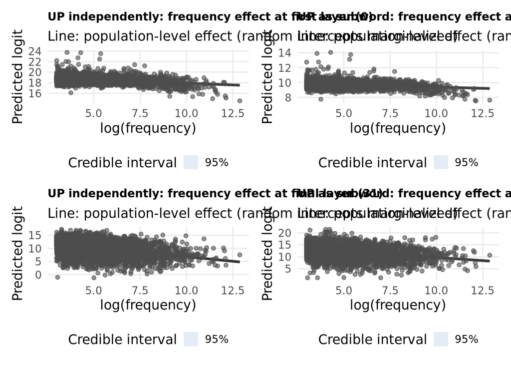

```r
p_indep_final = plot_final_layer(olmo_model_freq_up_independently,
  olmo_indep_final, "UP independently: frequency effect at final layer (31)")
p_sub_final   = plot_final_layer(olmo_model_freq_up_subword,
  olmo_sub_final,   "UP as subword: frequency effect at final layer (31)")
p_indep_first = plot_final_layer(olmo_model_freq_up_independently_first_layer,
  olmo_indep_first, "UP independently: frequency effect at first layer (0)")
p_sub_first   = plot_final_layer(olmo_model_freq_up_subword_first_layer,
  olmo_sub_first,   "UP as subword: frequency effect at first layer (0)")
(p_indep_first | p_sub_first) / (p_indep_final | p_sub_final)
```

### Frequency at first/final layer — bam plots

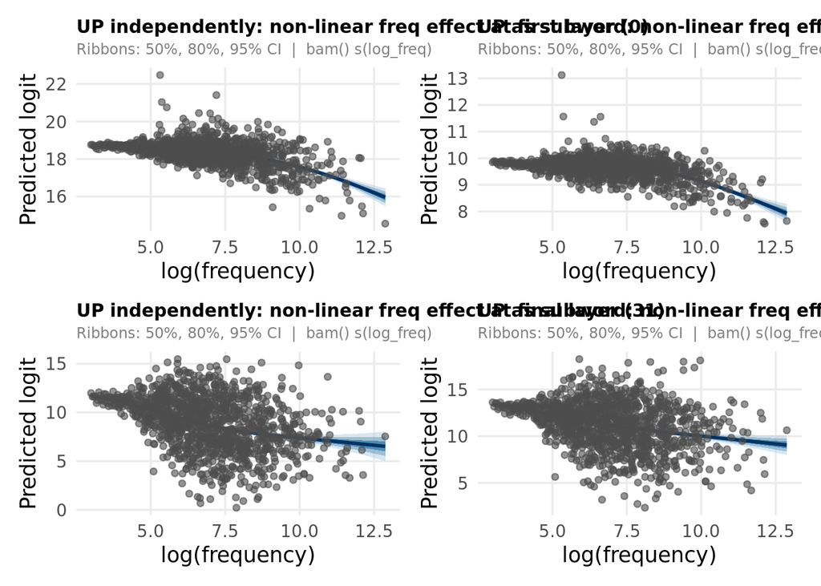

```r
p_bam_indep_final = plot_bam_single_layer(olmo_bam_freq_up_independently_final,
  olmo_indep_final, "UP independently: non-linear freq effect at final layer (31)")
p_bam_sub_final   = plot_bam_single_layer(olmo_bam_freq_up_subword_final,
  olmo_sub_final,   "UP as subword: non-linear freq effect at final layer (31)")
p_bam_indep_first = plot_bam_single_layer(olmo_bam_freq_up_independently_first,
  olmo_indep_first, "UP independently: non-linear freq effect at first layer (0)")
p_bam_sub_first   = plot_bam_single_layer(olmo_bam_freq_up_subword_first,
  olmo_sub_first,   "UP as subword: non-linear freq effect at first layer (0)")
(p_bam_indep_first | p_bam_sub_first) / (p_bam_indep_final | p_bam_sub_final)
```

### brms vs bam comparison (linearity check)

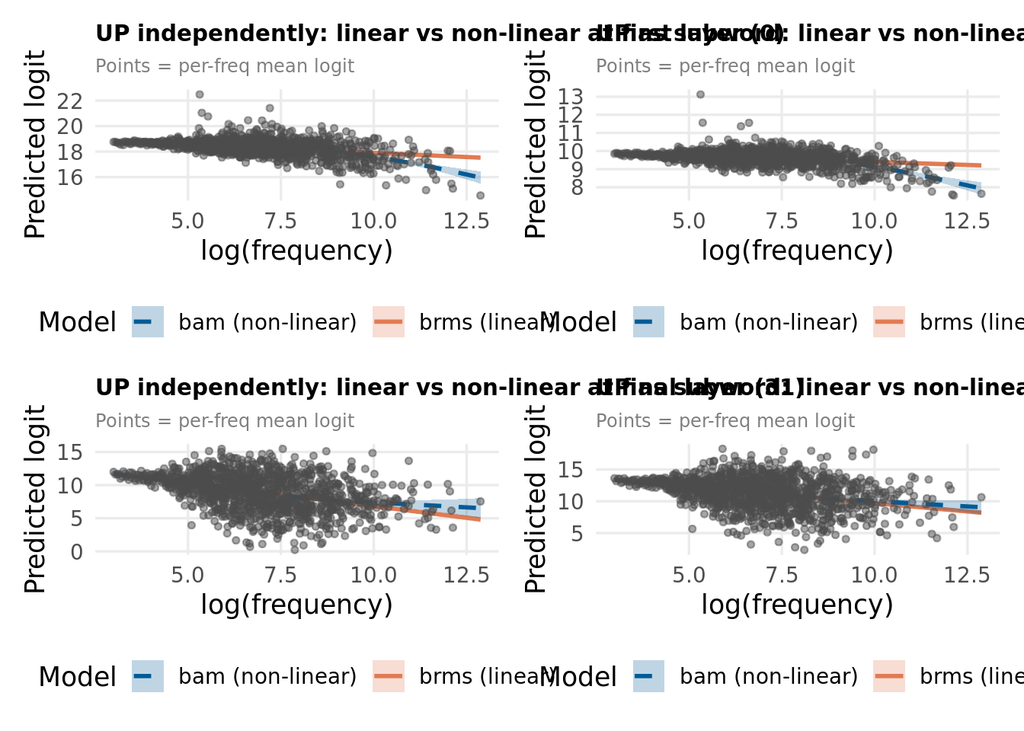

```r
p_cmp_indep_final = plot_brms_vs_bam(olmo_model_freq_up_independently,
  olmo_bam_freq_up_independently_final, olmo_indep_final,
  "UP independently: linear vs non-linear at final layer (31)")
p_cmp_sub_final = plot_brms_vs_bam(olmo_model_freq_up_subword,
  olmo_bam_freq_up_subword_final, olmo_sub_final,
  "UP as subword: linear vs non-linear at final layer (31)")
p_cmp_indep_first = plot_brms_vs_bam(olmo_model_freq_up_independently_first_layer,
  olmo_bam_freq_up_independently_first, olmo_indep_first,
  "UP independently: linear vs non-linear at first layer (0)")
p_cmp_sub_first = plot_brms_vs_bam(olmo_model_freq_up_subword_first_layer,
  olmo_bam_freq_up_subword_first, olmo_sub_first,
  "UP as subword: linear vs non-linear at first layer (0)")
(p_cmp_indep_first | p_cmp_sub_first) / (p_cmp_indep_final | p_cmp_sub_final)
```

### Frequency across all layers — plots

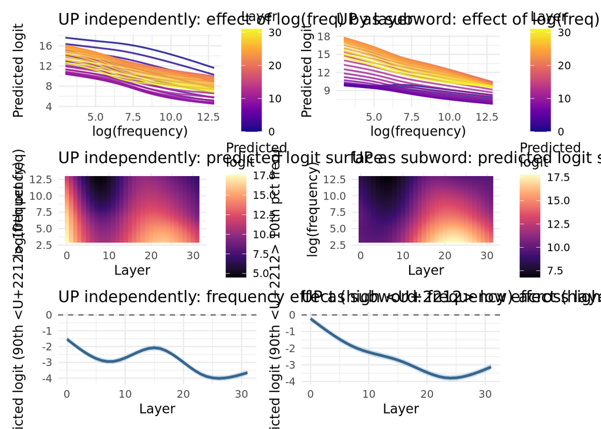

```r
plots_indep   = plot_freq_by_layer_mgcv(olmo_model_freq_layer_up_independently,
                                        olmo_indep, "UP independently", n_layers = 32)
plots_subword = plot_freq_by_layer_mgcv(olmo_model_freq_layer_up_subword,
                                        olmo_sub, "UP as subword", n_layers = 32)
(plots_indep$spaghetti + plots_subword$spaghetti) /
(plots_indep$heatmap   + plots_subword$heatmap)   /
(plots_indep$diff      + plots_subword$diff)
```

```r
plots_indep$surface3d
```

[interactive chart not shown]

```r
plots_subword$surface3d
```

[interactive chart not shown]

## OLMo — Predictability (FTP = P(up|V))

### Effect of FTP at the final layer (brms)

```r
olmo_indep_final_ftp  = olmo_indep %>% filter(layer == 31, !is.na(log_ftp)) %>%
  mutate(c_log_freq = c(scale(log_freq)), c_log_ftp = c(scale(log_ftp)))
olmo_sub_final_ftp    = olmo_sub   %>% filter(layer == 31, !is.na(log_ftp)) %>%
  mutate(c_log_freq = c(scale(log_freq)), c_log_ftp = c(scale(log_ftp)))

olmo_model_ftp_up_independently = brm(
  formula = logit ~ log_ftp + (1 | verb_up),
  data    = olmo_indep_final_ftp,
  prior   = priors,
  iter = 6000, warmup = 3000, chains = 4, cores = 4, seed = 964,
  file    = olmo_brms_path("model_ftp_up_independently")
)

olmo_model_ftp_up_subword = brm(
  formula = logit ~ log_ftp + (1 | verb_up),
  data    = olmo_sub_final_ftp,
  prior   = priors,
  iter = 6000, warmup = 3000, chains = 4, cores = 4, seed = 964,
  file    = olmo_brms_path("model_ftp_up_subword")
)
summary(olmo_model_ftp_up_independently)
```

```
##  Family: gaussian
##   Links: mu = identity
## Formula: logit ~ log_ftp + (1 | verb_up)
##    Data: olmo_indep_final_ftp (Number of observations: 78489)
##   Draws: 4 chains, each with iter = 6000; warmup = 3000; thin = 1;
##          total post-warmup draws = 12000
##
## Multilevel Hyperparameters:
## ~verb_up (Number of levels: 3927)
##               Estimate Est.Error l-95% CI u-95% CI Rhat Bulk_ESS Tail_ESS
## sd(Intercept)     2.33      0.03     2.27     2.39 1.00     2819     5199
##
## Regression Coefficients:
##           Estimate Est.Error l-95% CI u-95% CI Rhat Bulk_ESS Tail_ESS
## Intercept     6.27      0.09     6.09     6.46 1.00     2319     4412
## log_ftp      -0.78      0.02    -0.81    -0.74 1.00     2386     4303
##
## Further Distributional Parameters:
##       Estimate Est.Error l-95% CI u-95% CI Rhat Bulk_ESS Tail_ESS
## sigma     3.16      0.01     3.15     3.18 1.00    21733     8541
##
## Draws were sampled using sampling(NUTS). For each parameter, Bulk_ESS
## and Tail_ESS are effective sample size measures, and Rhat is the potential
## scale reduction factor on split chains (at convergence, Rhat = 1).
```

```r
summary(olmo_model_ftp_up_subword)
```

```
##  Family: gaussian
##   Links: mu = identity
## Formula: logit ~ log_ftp + (1 | verb_up)
##    Data: olmo_sub_final_ftp (Number of observations: 78489)
##   Draws: 4 chains, each with iter = 6000; warmup = 3000; thin = 1;
##          total post-warmup draws = 12000
##
## Multilevel Hyperparameters:
## ~verb_up (Number of levels: 3927)
##               Estimate Est.Error l-95% CI u-95% CI Rhat Bulk_ESS Tail_ESS
## sd(Intercept)     2.29      0.03     2.23     2.35 1.00     3698     5950
##
## Regression Coefficients:
##           Estimate Est.Error l-95% CI u-95% CI Rhat Bulk_ESS Tail_ESS
## Intercept     9.63      0.09     9.45     9.82 1.00     3311     6240
## log_ftp      -0.52      0.02    -0.55    -0.48 1.00     3238     6051
##
## Further Distributional Parameters:
##       Estimate Est.Error l-95% CI u-95% CI Rhat Bulk_ESS Tail_ESS
## sigma     3.64      0.01     3.62     3.66 1.00    19374     9031
##
## Draws were sampled using sampling(NUTS). For each parameter, Bulk_ESS
## and Tail_ESS are effective sample size measures, and Rhat is the potential
## scale reduction factor on split chains (at convergence, Rhat = 1).
```

### Effect of FTP at the first layer (brms)

```r
olmo_indep_first_ftp = olmo_indep %>% filter(layer == 0, !is.na(log_ftp)) %>%
  mutate(c_log_freq = c(scale(log_freq)), c_log_ftp = c(scale(log_ftp)))
olmo_sub_first_ftp   = olmo_sub   %>% filter(layer == 0, !is.na(log_ftp)) %>%
  mutate(c_log_freq = c(scale(log_freq)), c_log_ftp = c(scale(log_ftp)))

olmo_model_ftp_up_independently_first_layer = brm(
  formula = logit ~ log_ftp + (1 | verb_up),
  data    = olmo_indep_first_ftp,
  prior   = priors,
  iter = 6000, warmup = 3000, chains = 4, cores = 4, seed = 964,
  file    = olmo_brms_path("model_ftp_up_independently_first_layer")
)
olmo_model_ftp_up_subword_first_layer = brm(
  formula = logit ~ log_ftp + (1 | verb_up),
  data    = olmo_sub_first_ftp,
  prior   = priors,
  iter = 6000, warmup = 3000, chains = 4, cores = 4, seed = 964,
  file    = olmo_brms_path("model_ftp_up_subword_first_layer")
)
summary(olmo_model_ftp_up_independently_first_layer)
```

```
##  Family: gaussian
##   Links: mu = identity
## Formula: logit ~ log_ftp + (1 | verb_up)
##    Data: olmo_indep_first_ftp (Number of observations: 78489)
##   Draws: 4 chains, each with iter = 6000; warmup = 3000; thin = 1;
##          total post-warmup draws = 12000
##
## Multilevel Hyperparameters:
## ~verb_up (Number of levels: 3927)
##               Estimate Est.Error l-95% CI u-95% CI Rhat Bulk_ESS Tail_ESS
## sd(Intercept)     0.60      0.01     0.58     0.61 1.00     3068     5553
##
## Regression Coefficients:
##           Estimate Est.Error l-95% CI u-95% CI Rhat Bulk_ESS Tail_ESS
## Intercept    18.14      0.02    18.10    18.19 1.00     2545     4472
## log_ftp      -0.08      0.00    -0.09    -0.07 1.00     2486     4235
##
## Further Distributional Parameters:
##       Estimate Est.Error l-95% CI u-95% CI Rhat Bulk_ESS Tail_ESS
## sigma     0.79      0.00     0.79     0.80 1.00    18381     8565
##
## Draws were sampled using sampling(NUTS). For each parameter, Bulk_ESS
## and Tail_ESS are effective sample size measures, and Rhat is the potential
## scale reduction factor on split chains (at convergence, Rhat = 1).
```

```r
summary(olmo_model_ftp_up_subword_first_layer)
```

```
##  Family: gaussian
##   Links: mu = identity
## Formula: logit ~ log_ftp + (1 | verb_up)
##    Data: olmo_sub_first_ftp (Number of observations: 78489)
##   Draws: 4 chains, each with iter = 6000; warmup = 3000; thin = 1;
##          total post-warmup draws = 12000
##
## Multilevel Hyperparameters:
## ~verb_up (Number of levels: 3927)
##               Estimate Est.Error l-95% CI u-95% CI Rhat Bulk_ESS Tail_ESS
## sd(Intercept)     0.42      0.01     0.41     0.43 1.00     3240     5739
##
## Regression Coefficients:
##           Estimate Est.Error l-95% CI u-95% CI Rhat Bulk_ESS Tail_ESS
## Intercept     9.69      0.02     9.66     9.72 1.00     2740     4642
## log_ftp      -0.01      0.00    -0.01    -0.00 1.00     2716     4811
##
## Further Distributional Parameters:
##       Estimate Est.Error l-95% CI u-95% CI Rhat Bulk_ESS Tail_ESS
## sigma     0.63      0.00     0.63     0.63 1.00    19585     9254
##
## Draws were sampled using sampling(NUTS). For each parameter, Bulk_ESS
## and Tail_ESS are effective sample size measures, and Rhat is the potential
## scale reduction factor on split chains (at convergence, Rhat = 1).
```

### Effect of FTP at the final layer (bam — non-linear)

```r
set.seed(964)
olmo_bam_ftp_up_independently_final = olmo_cache_bam("bam_ftp_up_independently_final", function() {
  bam(logit ~ s(log_ftp) + s(verb_up, bs = 're'),
      data = olmo_indep_final_ftp, method = 'fREML', discrete = TRUE)
})
olmo_bam_ftp_up_subword_final = olmo_cache_bam("bam_ftp_up_subword_final", function() {
  bam(logit ~ s(log_ftp) + s(verb_up, bs = 're'),
      data = olmo_sub_final_ftp, method = 'fREML', discrete = TRUE)
})
summary(olmo_bam_ftp_up_independently_final)
```

```
##
## Family: gaussian
## Link function: identity
##
## Formula:
## logit ~ s(log_ftp) + s(verb_up, bs = "re")
##
## Parametric coefficients:
##             Estimate Std. Error t value Pr(>|t|)
## (Intercept)  9.69060    0.04693   206.5   <2e-16 ***
## ---
## Signif. codes:  0 '***' 0.001 '**' 0.01 '*' 0.05 '.' 0.1 ' ' 1
##
## Approximate significance of smooth terms:
##                 edf   Ref.df      F p-value
## s(log_ftp)    5.365    5.464 408.56  <2e-16 ***
## s(verb_up) 3585.213 3925.000  11.01  <2e-16 ***
## ---
## Signif. codes:  0 '***' 0.001 '**' 0.01 '*' 0.05 '.' 0.1 ' ' 1
##
## R-sq.(adj) =  0.464   Deviance explained = 48.9%
## fREML = 2.0654e+05  Scale est. = 9.9917    n = 78489
```

```r
summary(olmo_bam_ftp_up_subword_final)
```

```
##
## Family: gaussian
## Link function: identity
##
## Formula:
## logit ~ s(log_ftp) + s(verb_up, bs = "re")
##
## Parametric coefficients:
##             Estimate Std. Error t value Pr(>|t|)
## (Intercept) 11.85209    0.04673   253.7   <2e-16 ***
## ---
## Signif. codes:  0 '***' 0.001 '**' 0.01 '*' 0.05 '.' 0.1 ' ' 1
##
## Approximate significance of smooth terms:
##                 edf   Ref.df       F p-value
## s(log_ftp)    4.652    4.775 207.404  <2e-16 ***
## s(verb_up) 3478.106 3925.000   8.157  <2e-16 ***
## ---
## Signif. codes:  0 '***' 0.001 '**' 0.01 '*' 0.05 '.' 0.1 ' ' 1
##
## R-sq.(adj) =  0.335   Deviance explained = 36.4%
## fREML = 2.1701e+05  Scale est. = 13.228    n = 78489
```

### Effect of FTP across layers (mgcv)

```r
olmo_indep_ftp   = olmo_indep %>% filter(!is.na(log_ftp))
olmo_subword_ftp = olmo_sub   %>% filter(!is.na(log_ftp))

set.seed(964)
olmo_model_ftp_layer_up_independently = olmo_cache_bam("model_ftp_layer_up_independently", function() {
  bam(logit ~ te(log_ftp, layer) + s(verb_up, bs = 're'),
      data = olmo_indep_ftp, method = 'fREML', discrete = TRUE)
})
olmo_model_ftp_layer_up_subword = olmo_cache_bam("model_ftp_layer_up_subword", function() {
  bam(logit ~ te(log_ftp, layer) + s(verb_up, bs = 're'),
      data = olmo_subword_ftp, method = 'fREML', discrete = TRUE)
})
summary(olmo_model_ftp_layer_up_independently)
```

```
##
## Family: gaussian
## Link function: identity
##
## Formula:
## logit ~ te(log_ftp, layer) + s(verb_up, bs = "re")
##
## Parametric coefficients:
##             Estimate Std. Error t value Pr(>|t|)
## (Intercept) 12.08439    0.03621   333.7   <2e-16 ***
## ---
## Signif. codes:  0 '***' 0.001 '**' 0.01 '*' 0.05 '.' 0.1 ' ' 1
##
## Approximate significance of smooth terms:
##                       edf  Ref.df       F p-value
## te(log_ftp,layer)   23.27   23.31 40412.5  <2e-16 ***
## s(verb_up)        3903.69 3925.00   758.5  <2e-16 ***
## ---
## Signif. codes:  0 '***' 0.001 '**' 0.01 '*' 0.05 '.' 0.1 ' ' 1
##
## R-sq.(adj) =  0.458   Deviance explained = 45.9%
## fREML = 6.5872e+06  Scale est. = 11.012    n = 2511648
```

```r
summary(olmo_model_ftp_layer_up_subword)
```

```
##
## Family: gaussian
## Link function: identity
##
## Formula:
## logit ~ te(log_ftp, layer) + s(verb_up, bs = "re")
##
## Parametric coefficients:
##             Estimate Std. Error t value Pr(>|t|)
## (Intercept) 12.60498    0.03897   323.4   <2e-16 ***
## ---
## Signif. codes:  0 '***' 0.001 '**' 0.01 '*' 0.05 '.' 0.1 ' ' 1
##
## Approximate significance of smooth terms:
##                       edf  Ref.df       F p-value
## te(log_ftp,layer)   22.71   22.82 52462.6  <2e-16 ***
## s(verb_up)        3902.13 3925.00   595.7  <2e-16 ***
## ---
## Signif. codes:  0 '***' 0.001 '**' 0.01 '*' 0.05 '.' 0.1 ' ' 1
##
## R-sq.(adj) =  0.462   Deviance explained = 46.3%
## fREML = 6.92e+06  Scale est. = 14.357    n = 2511648
```

### FTP across layers — plots

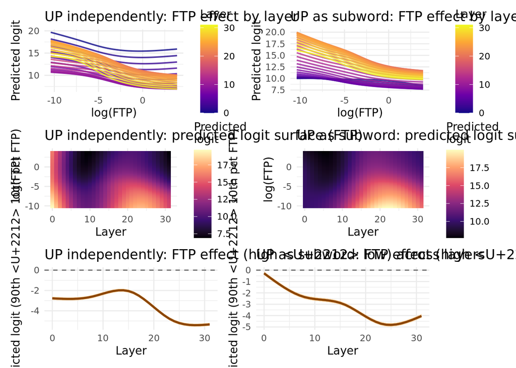

```r
plots_ftp_indep   = plot_ftp_by_layer_mgcv(olmo_model_ftp_layer_up_independently,
                                            olmo_indep_ftp, "UP independently", n_layers = 32)
plots_ftp_subword = plot_ftp_by_layer_mgcv(olmo_model_ftp_layer_up_subword,
                                            olmo_subword_ftp, "UP as subword", n_layers = 32)
(plots_ftp_indep$spaghetti + plots_ftp_subword$spaghetti) /
(plots_ftp_indep$heatmap   + plots_ftp_subword$heatmap)   /
(plots_ftp_indep$diff      + plots_ftp_subword$diff)
```

## OLMo — Joint frequency + predictability

### Additive freq + FTP at the final layer (brms)

```r
olmo_model_freq_ftp_up_independently = brm(
  formula = logit ~ c_log_freq * c_log_ftp + (1 | verb_up),
  data    = olmo_indep_final_ftp,
  prior   = priors,
  iter = 6000, warmup = 3000, chains = 4, cores = 4, seed = 964,
  file    = olmo_brms_path("model_freq_ftp_up_independently")
)
olmo_model_freq_ftp_up_subword = brm(
  formula = logit ~ c_log_freq * c_log_ftp + (1 | verb_up),
  data    = olmo_sub_final_ftp,
  prior   = priors,
  iter = 6000, warmup = 3000, chains = 4, cores = 4, seed = 964,
  file    = olmo_brms_path("model_freq_ftp_up_subword")
)
summary(olmo_model_freq_ftp_up_independently)
```

```
##  Family: gaussian
##   Links: mu = identity
## Formula: logit ~ c_log_freq * c_log_ftp + (1 | verb_up)
##    Data: olmo_indep_final_ftp (Number of observations: 78489)
##   Draws: 4 chains, each with iter = 6000; warmup = 3000; thin = 1;
##          total post-warmup draws = 12000
##
## Multilevel Hyperparameters:
## ~verb_up (Number of levels: 3927)
##               Estimate Est.Error l-95% CI u-95% CI Rhat Bulk_ESS Tail_ESS
## sd(Intercept)     2.28      0.03     2.22     2.34 1.00     2856     5420
##
## Regression Coefficients:
##                      Estimate Est.Error l-95% CI u-95% CI Rhat Bulk_ESS
## Intercept               10.27      0.04    10.18    10.35 1.00     2258
## c_log_freq              -0.54      0.05    -0.63    -0.45 1.00     1715
## c_log_ftp               -1.56      0.04    -1.64    -1.48 1.00     2128
## c_log_freq:c_log_ftp     0.00      0.04    -0.08     0.08 1.00     1976
##                      Tail_ESS
## Intercept                4016
## c_log_freq               3673
## c_log_ftp                3790
## c_log_freq:c_log_ftp     4154
##
## Further Distributional Parameters:
##       Estimate Est.Error l-95% CI u-95% CI Rhat Bulk_ESS Tail_ESS
## sigma     3.16      0.01     3.14     3.18 1.00    21420     7908
##
## Draws were sampled using sampling(NUTS). For each parameter, Bulk_ESS
## and Tail_ESS are effective sample size measures, and Rhat is the potential
## scale reduction factor on split chains (at convergence, Rhat = 1).
```

```r
summary(olmo_model_freq_ftp_up_subword)
```

```
##  Family: gaussian
##   Links: mu = identity
## Formula: logit ~ c_log_freq * c_log_ftp + (1 | verb_up)
##    Data: olmo_sub_final_ftp (Number of observations: 78489)
##   Draws: 4 chains, each with iter = 6000; warmup = 3000; thin = 1;
##          total post-warmup draws = 12000
##
## Multilevel Hyperparameters:
## ~verb_up (Number of levels: 3927)
##               Estimate Est.Error l-95% CI u-95% CI Rhat Bulk_ESS Tail_ESS
## sd(Intercept)     2.25      0.03     2.19     2.30 1.00     3465     6494
##
## Regression Coefficients:
##                      Estimate Est.Error l-95% CI u-95% CI Rhat Bulk_ESS
## Intercept               12.32      0.04    12.24    12.40 1.00     3056
## c_log_freq              -0.45      0.05    -0.54    -0.36 1.00     3228
## c_log_ftp               -0.99      0.04    -1.07    -0.91 1.00     2955
## c_log_freq:c_log_ftp    -0.06      0.04    -0.15     0.02 1.00     3169
##                      Tail_ESS
## Intercept                4883
## c_log_freq               4998
## c_log_ftp                5299
## c_log_freq:c_log_ftp     5381
##
## Further Distributional Parameters:
##       Estimate Est.Error l-95% CI u-95% CI Rhat Bulk_ESS Tail_ESS
## sigma     3.64      0.01     3.62     3.66 1.00    22321     8572
##
## Draws were sampled using sampling(NUTS). For each parameter, Bulk_ESS
## and Tail_ESS are effective sample size measures, and Rhat is the potential
## scale reduction factor on split chains (at convergence, Rhat = 1).
```

### Additive freq + FTP at the first layer (brms)

```r
olmo_model_freq_ftp_up_independently_first = brm(
  formula = logit ~ c_log_freq * c_log_ftp + (1 | verb_up),
  data    = olmo_indep_first_ftp,
  prior   = priors,
  iter = 6000, warmup = 3000, chains = 4, cores = 4, seed = 964,
  file    = olmo_brms_path("model_freq_ftp_up_independently_first")
)
olmo_model_freq_ftp_up_subword_first = brm(
  formula = logit ~ c_log_freq * c_log_ftp + (1 | verb_up),
  data    = olmo_sub_first_ftp,
  prior   = priors,
  iter = 6000, warmup = 3000, chains = 4, cores = 4, seed = 964,
  file    = olmo_brms_path("model_freq_ftp_up_subword_first")
)
summary(olmo_model_freq_ftp_up_independently_first)
```

```
##  Family: gaussian
##   Links: mu = identity
## Formula: logit ~ c_log_freq * c_log_ftp + (1 | verb_up)
##    Data: olmo_indep_first_ftp (Number of observations: 78489)
##   Draws: 4 chains, each with iter = 6000; warmup = 3000; thin = 1;
##          total post-warmup draws = 12000
##
## Multilevel Hyperparameters:
## ~verb_up (Number of levels: 3927)
##               Estimate Est.Error l-95% CI u-95% CI Rhat Bulk_ESS Tail_ESS
## sd(Intercept)     0.57      0.01     0.55     0.58 1.00     3018     5430
##
## Regression Coefficients:
##                      Estimate Est.Error l-95% CI u-95% CI Rhat Bulk_ESS
## Intercept               18.58      0.01    18.56    18.60 1.00     1936
## c_log_freq              -0.14      0.01    -0.16    -0.12 1.00     2024
## c_log_ftp               -0.11      0.01    -0.13    -0.09 1.00     1890
## c_log_freq:c_log_ftp    -0.09      0.01    -0.11    -0.07 1.00     2139
##                      Tail_ESS
## Intercept                3692
## c_log_freq               3893
## c_log_ftp                4054
## c_log_freq:c_log_ftp     4177
##
## Further Distributional Parameters:
##       Estimate Est.Error l-95% CI u-95% CI Rhat Bulk_ESS Tail_ESS
## sigma     0.79      0.00     0.79     0.80 1.00    23447     8291
##
## Draws were sampled using sampling(NUTS). For each parameter, Bulk_ESS
## and Tail_ESS are effective sample size measures, and Rhat is the potential
## scale reduction factor on split chains (at convergence, Rhat = 1).
```

```r
summary(olmo_model_freq_ftp_up_subword_first)
```

```
##  Family: gaussian
##   Links: mu = identity
## Formula: logit ~ c_log_freq * c_log_ftp + (1 | verb_up)
##    Data: olmo_sub_first_ftp (Number of observations: 78489)
##   Draws: 4 chains, each with iter = 6000; warmup = 3000; thin = 1;
##          total post-warmup draws = 12000
##
## Multilevel Hyperparameters:
## ~verb_up (Number of levels: 3927)
##               Estimate Est.Error l-95% CI u-95% CI Rhat Bulk_ESS Tail_ESS
## sd(Intercept)     0.40      0.01     0.39     0.41 1.00     3279     5669
##
## Regression Coefficients:
##                      Estimate Est.Error l-95% CI u-95% CI Rhat Bulk_ESS
## Intercept                9.74      0.01     9.72     9.75 1.00     2660
## c_log_freq              -0.13      0.01    -0.14    -0.11 1.00     3141
## c_log_ftp                0.04      0.01     0.02     0.05 1.00     3006
## c_log_freq:c_log_ftp    -0.02      0.01    -0.03    -0.00 1.00     3046
##                      Tail_ESS
## Intercept                5199
## c_log_freq               5325
## c_log_ftp                5270
## c_log_freq:c_log_ftp     4833
##
## Further Distributional Parameters:
##       Estimate Est.Error l-95% CI u-95% CI Rhat Bulk_ESS Tail_ESS
## sigma     0.63      0.00     0.63     0.63 1.00    21702     7805
##
## Draws were sampled using sampling(NUTS). For each parameter, Bulk_ESS
## and Tail_ESS are effective sample size measures, and Rhat is the potential
## scale reduction factor on split chains (at convergence, Rhat = 1).
```

### Polynomial freq² + FTP² joint at the final layer (brms)

```r
olmo_model_poly_joint_indep_final = brm(
  formula = logit ~ c_log_freq + I(c_log_freq^2) + c_log_ftp + I(c_log_ftp^2) + c_log_freq:c_log_ftp + (1 | verb_up),
  data    = olmo_indep_final_ftp,
  prior   = priors,
  iter = 6000, warmup = 3000, chains = 4, cores = 4, seed = 964,
  file    = olmo_brms_path("model_poly_joint_indep_final")
)
olmo_model_poly_joint_sub_final = brm(
  formula = logit ~ c_log_freq + I(c_log_freq^2) + c_log_ftp + I(c_log_ftp^2) + c_log_freq:c_log_ftp + (1 | verb_up),
  data    = olmo_sub_final_ftp,
  prior   = priors,
  iter = 6000, warmup = 3000, chains = 4, cores = 4, seed = 964,
  file    = olmo_brms_path("model_poly_joint_sub_final")
)
summary(olmo_model_poly_joint_indep_final)
```

```
##  Family: gaussian
##   Links: mu = identity
## Formula: logit ~ c_log_freq + I(c_log_freq^2) + c_log_ftp + I(c_log_ftp^2) + c_log_freq:c_log_ftp + (1 | verb_up)
##    Data: olmo_indep_final_ftp (Number of observations: 78489)
##   Draws: 4 chains, each with iter = 6000; warmup = 3000; thin = 1;
##          total post-warmup draws = 12000
##
## Multilevel Hyperparameters:
## ~verb_up (Number of levels: 3927)
##               Estimate Est.Error l-95% CI u-95% CI Rhat Bulk_ESS Tail_ESS
## sd(Intercept)     2.28      0.03     2.22     2.33 1.00     1779     3887
##
## Regression Coefficients:
##                      Estimate Est.Error l-95% CI u-95% CI Rhat Bulk_ESS
## Intercept               10.14      0.06    10.03    10.25 1.00     1322
## c_log_freq              -0.58      0.06    -0.69    -0.46 1.00     1144
## Ic_log_freqE2            0.09      0.04     0.02     0.16 1.00     1524
## c_log_ftp               -1.62      0.05    -1.71    -1.52 1.00     1188
## Ic_log_ftpE2             0.09      0.03     0.02     0.15 1.00     1356
## c_log_freq:c_log_ftp    -0.12      0.06    -0.23    -0.01 1.00     1346
##                      Tail_ESS
## Intercept                2379
## c_log_freq               2414
## Ic_log_freqE2            3056
## c_log_ftp                2432
## Ic_log_ftpE2             2678
## c_log_freq:c_log_ftp     2582
##
## Further Distributional Parameters:
##       Estimate Est.Error l-95% CI u-95% CI Rhat Bulk_ESS Tail_ESS
## sigma     3.16      0.01     3.15     3.18 1.00    20619     8592
##
## Draws were sampled using sampling(NUTS). For each parameter, Bulk_ESS
## and Tail_ESS are effective sample size measures, and Rhat is the potential
## scale reduction factor on split chains (at convergence, Rhat = 1).
```

```r
summary(olmo_model_poly_joint_sub_final)
```

```
##  Family: gaussian
##   Links: mu = identity
## Formula: logit ~ c_log_freq + I(c_log_freq^2) + c_log_ftp + I(c_log_ftp^2) + c_log_freq:c_log_ftp + (1 | verb_up)
##    Data: olmo_sub_final_ftp (Number of observations: 78489)
##   Draws: 4 chains, each with iter = 6000; warmup = 3000; thin = 1;
##          total post-warmup draws = 12000
##
## Multilevel Hyperparameters:
## ~verb_up (Number of levels: 3927)
##               Estimate Est.Error l-95% CI u-95% CI Rhat Bulk_ESS Tail_ESS
## sd(Intercept)     2.25      0.03     2.19     2.31 1.00     2994     6170
##
## Regression Coefficients:
##                      Estimate Est.Error l-95% CI u-95% CI Rhat Bulk_ESS
## Intercept               12.29      0.06    12.18    12.40 1.00     2340
## c_log_freq              -0.53      0.06    -0.64    -0.42 1.00     1968
## Ic_log_freqE2            0.07      0.04     0.00     0.14 1.00     2028
## c_log_ftp               -0.97      0.05    -1.06    -0.87 1.00     1924
## Ic_log_ftpE2            -0.03      0.03    -0.10     0.03 1.00     1965
## c_log_freq:c_log_ftp    -0.09      0.06    -0.20     0.02 1.00     1978
##                      Tail_ESS
## Intercept                3579
## c_log_freq               3719
## Ic_log_freqE2            3653
## c_log_ftp                3878
## Ic_log_ftpE2             3918
## c_log_freq:c_log_ftp     3966
##
## Further Distributional Parameters:
##       Estimate Est.Error l-95% CI u-95% CI Rhat Bulk_ESS Tail_ESS
## sigma     3.64      0.01     3.62     3.66 1.00    24460     8453
##
## Draws were sampled using sampling(NUTS). For each parameter, Bulk_ESS
## and Tail_ESS are effective sample size measures, and Rhat is the potential
## scale reduction factor on split chains (at convergence, Rhat = 1).
```

### Polynomial freq² + FTP² joint at the first layer (brms)

```r
olmo_model_poly_joint_indep_first = brm(
  formula = logit ~ c_log_freq + I(c_log_freq^2) + c_log_ftp + I(c_log_ftp^2) + c_log_freq:c_log_ftp + (1 | verb_up),
  data    = olmo_indep_first_ftp,
  prior   = priors,
  iter = 6000, warmup = 3000, chains = 4, cores = 4, seed = 964,
  file    = olmo_brms_path("model_poly_joint_indep_first")
)
olmo_model_poly_joint_sub_first = brm(
  formula = logit ~ c_log_freq + I(c_log_freq^2) + c_log_ftp + I(c_log_ftp^2) + c_log_freq:c_log_ftp + (1 | verb_up),
  data    = olmo_sub_first_ftp,
  prior   = priors,
  iter = 6000, warmup = 3000, chains = 4, cores = 4, seed = 964,
  file    = olmo_brms_path("model_poly_joint_sub_first")
)
summary(olmo_model_poly_joint_indep_first)
```

```
##  Family: gaussian
##   Links: mu = identity
## Formula: logit ~ c_log_freq + I(c_log_freq^2) + c_log_ftp + I(c_log_ftp^2) + c_log_freq:c_log_ftp + (1 | verb_up)
##    Data: olmo_indep_first_ftp (Number of observations: 78489)
##   Draws: 4 chains, each with iter = 6000; warmup = 3000; thin = 1;
##          total post-warmup draws = 12000
##
## Multilevel Hyperparameters:
## ~verb_up (Number of levels: 3927)
##               Estimate Est.Error l-95% CI u-95% CI Rhat Bulk_ESS Tail_ESS
## sd(Intercept)     0.55      0.01     0.53     0.56 1.00     2279     4279
##
## Regression Coefficients:
##                      Estimate Est.Error l-95% CI u-95% CI Rhat Bulk_ESS
## Intercept               18.53      0.01    18.50    18.56 1.00     1494
## c_log_freq              -0.05      0.01    -0.08    -0.03 1.00     1324
## Ic_log_freqE2           -0.04      0.01    -0.06    -0.03 1.00     1246
## c_log_ftp               -0.18      0.01    -0.21    -0.16 1.00     1245
## Ic_log_ftpE2             0.11      0.01     0.09     0.13 1.00     1525
## c_log_freq:c_log_ftp    -0.13      0.01    -0.16    -0.10 1.00     1336
##                      Tail_ESS
## Intercept                2798
## c_log_freq               2564
## Ic_log_freqE2            2624
## c_log_ftp                2683
## Ic_log_ftpE2             2912
## c_log_freq:c_log_ftp     2419
##
## Further Distributional Parameters:
##       Estimate Est.Error l-95% CI u-95% CI Rhat Bulk_ESS Tail_ESS
## sigma     0.79      0.00     0.79     0.80 1.00    22744     8512
##
## Draws were sampled using sampling(NUTS). For each parameter, Bulk_ESS
## and Tail_ESS are effective sample size measures, and Rhat is the potential
## scale reduction factor on split chains (at convergence, Rhat = 1).
```

```r
summary(olmo_model_poly_joint_sub_first)
```

```
##  Family: gaussian
##   Links: mu = identity
## Formula: logit ~ c_log_freq + I(c_log_freq^2) + c_log_ftp + I(c_log_ftp^2) + c_log_freq:c_log_ftp + (1 | verb_up)
##    Data: olmo_sub_first_ftp (Number of observations: 78489)
##   Draws: 4 chains, each with iter = 6000; warmup = 3000; thin = 1;
##          total post-warmup draws = 12000
##
## Multilevel Hyperparameters:
## ~verb_up (Number of levels: 3927)
##               Estimate Est.Error l-95% CI u-95% CI Rhat Bulk_ESS Tail_ESS
## sd(Intercept)     0.39      0.01     0.38     0.40 1.00     2459     5288
##
## Regression Coefficients:
##                      Estimate Est.Error l-95% CI u-95% CI Rhat Bulk_ESS
## Intercept                9.80      0.01     9.78     9.82 1.00     1931
## c_log_freq              -0.08      0.01    -0.10    -0.07 1.00     2175
## Ic_log_freqE2           -0.07      0.01    -0.08    -0.05 1.00     2222
## c_log_ftp                0.05      0.01     0.04     0.07 1.00     1946
## Ic_log_ftpE2            -0.02      0.01    -0.04    -0.01 1.00     2099
## c_log_freq:c_log_ftp     0.04      0.01     0.02     0.06 1.00     2089
##                      Tail_ESS
## Intercept                3699
## c_log_freq               4008
## Ic_log_freqE2            3740
## c_log_ftp                3894
## Ic_log_ftpE2             3483
## c_log_freq:c_log_ftp     3654
##
## Further Distributional Parameters:
##       Estimate Est.Error l-95% CI u-95% CI Rhat Bulk_ESS Tail_ESS
## sigma     0.63      0.00     0.63     0.63 1.00    23867     8468
##
## Draws were sampled using sampling(NUTS). For each parameter, Bulk_ESS
## and Tail_ESS are effective sample size measures, and Rhat is the potential
## scale reduction factor on split chains (at convergence, Rhat = 1).
```

### Joint freq × FTP surface at final layer (bam)

```r
set.seed(964)
olmo_bam_joint_up_independently_final = olmo_cache_bam("bam_joint_up_independently_final", function() {
  bam(logit ~ te(log_freq, log_ftp) + s(verb_up, bs = 're'),
      data = olmo_indep_final_ftp, method = 'fREML', discrete = TRUE)
})
olmo_bam_joint_up_subword_final = olmo_cache_bam("bam_joint_up_subword_final", function() {
  bam(logit ~ te(log_freq, log_ftp) + s(verb_up, bs = 're'),
      data = olmo_sub_final_ftp, method = 'fREML', discrete = TRUE)
})
summary(olmo_bam_joint_up_independently_final)
```

```
##
## Family: gaussian
## Link function: identity
##
## Formula:
## logit ~ te(log_freq, log_ftp) + s(verb_up, bs = "re")
##
## Parametric coefficients:
##             Estimate Std. Error t value Pr(>|t|)
## (Intercept)   9.3647     0.1164   80.46   <2e-16 ***
## ---
## Signif. codes:  0 '***' 0.001 '**' 0.01 '*' 0.05 '.' 0.1 ' ' 1
##
## Approximate significance of smooth terms:
##                          edf  Ref.df     F p-value
## te(log_freq,log_ftp)   10.21   10.41 239.2  <2e-16 ***
## s(verb_up)           3566.70 3923.00  11.2  <2e-16 ***
## ---
## Signif. codes:  0 '***' 0.001 '**' 0.01 '*' 0.05 '.' 0.1 ' ' 1
##
## R-sq.(adj) =  0.464   Deviance explained = 48.9%
## fREML = 2.0646e+05  Scale est. = 9.9917    n = 78489
```

```r
summary(olmo_bam_joint_up_subword_final)
```

```
##
## Family: gaussian
## Link function: identity
##
## Formula:
## logit ~ te(log_freq, log_ftp) + s(verb_up, bs = "re")
##
## Parametric coefficients:
##             Estimate Std. Error t value Pr(>|t|)
## (Intercept)  11.4791     0.1019   112.7   <2e-16 ***
## ---
## Signif. codes:  0 '***' 0.001 '**' 0.01 '*' 0.05 '.' 0.1 ' ' 1
##
## Approximate significance of smooth terms:
##                           edf   Ref.df       F p-value
## te(log_freq,log_ftp)    8.781    9.033 126.487  <2e-16 ***
## s(verb_up)           3459.924 3923.000   8.291  <2e-16 ***
## ---
## Signif. codes:  0 '***' 0.001 '**' 0.01 '*' 0.05 '.' 0.1 ' ' 1
##
## R-sq.(adj) =  0.335   Deviance explained = 36.4%
## fREML = 2.1695e+05  Scale est. = 13.228    n = 78489
```

### Joint surface plots

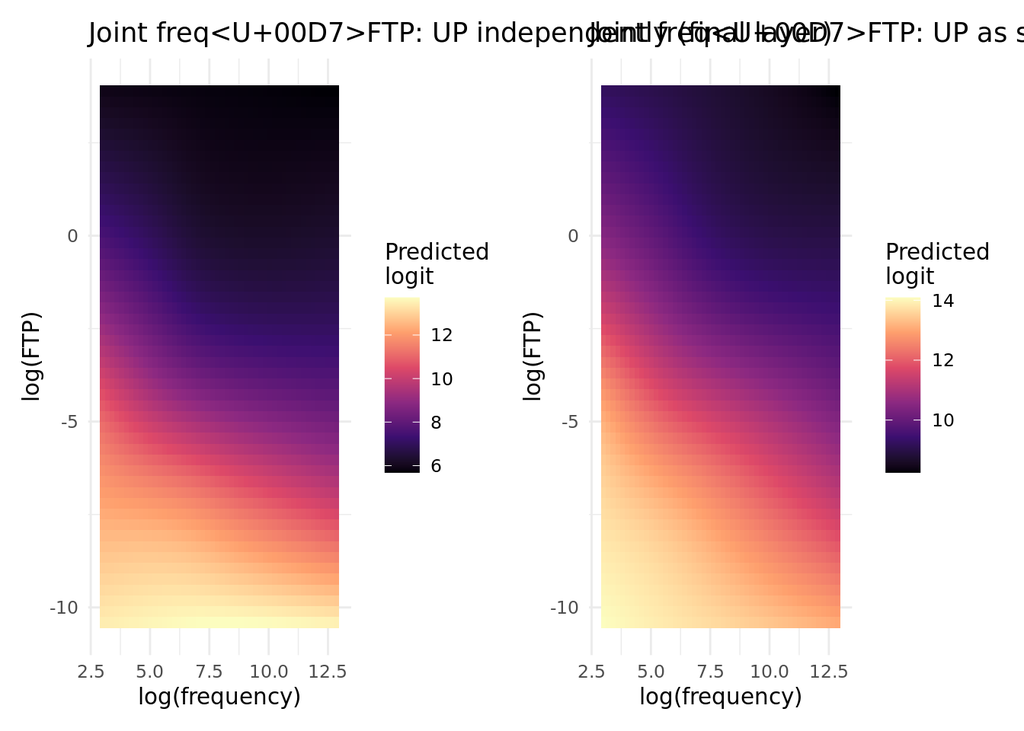

```r
joint_indep   = plot_joint_surface(olmo_bam_joint_up_independently_final,
                                   olmo_indep_final_ftp, "Joint freq×FTP: UP independently (final layer)")
joint_subword = plot_joint_surface(olmo_bam_joint_up_subword_final,
                                   olmo_sub_final_ftp, "Joint freq×FTP: UP as subword (final layer)")
joint_indep$heatmap + joint_subword$heatmap
```

```r
joint_indep$surface3d
```

[interactive chart not shown]

```r
joint_subword$surface3d
```

[interactive chart not shown]

### Freq and FTP effects across layers (additive bam)

```r
set.seed(964)
olmo_model_freq_ftp_layer_up_independently = olmo_cache_bam("model_freq_ftp_layer_up_independently", function() {
  bam(logit ~ te(log_freq, layer) + te(log_ftp, layer) + s(verb_up, bs = 're'),
      data = olmo_indep_ftp, method = 'fREML', discrete = TRUE)
})
olmo_model_freq_ftp_layer_up_subword = olmo_cache_bam("model_freq_ftp_layer_up_subword", function() {
  bam(logit ~ te(log_freq, layer) + te(log_ftp, layer) + s(verb_up, bs = 're'),
      data = olmo_subword_ftp, method = 'fREML', discrete = TRUE)
})
summary(olmo_model_freq_ftp_layer_up_independently)
```

```
##
## Family: gaussian
## Link function: identity
##
## Formula:
## logit ~ te(log_freq, layer) + te(log_ftp, layer) + s(verb_up,
##     bs = "re")
##
## Parametric coefficients:
##             Estimate Std. Error t value Pr(>|t|)
## (Intercept) 11.36661    0.04588   247.7   <2e-16 ***
## ---
## Signif. codes:  0 '***' 0.001 '**' 0.01 '*' 0.05 '.' 0.1 ' ' 1
##
## Approximate significance of smooth terms:
##                        edf  Ref.df      F p-value
## te(log_freq,layer)   19.62   19.83  323.9  <2e-16 ***
## te(log_ftp,layer)    22.08   22.13 2005.9  <2e-16 ***
## s(verb_up)         3898.49 3924.00  665.8  <2e-16 ***
## ---
## Signif. codes:  0 '***' 0.001 '**' 0.01 '*' 0.05 '.' 0.1 ' ' 1
##
## R-sq.(adj) =  0.267   Deviance explained = 26.8%
## fREML = 6.5838e+06  Scale est. = 10.985    n = 2511648
```

```r
summary(olmo_model_freq_ftp_layer_up_subword)
```

```
##
## Family: gaussian
## Link function: identity
##
## Formula:
## logit ~ te(log_freq, layer) + te(log_ftp, layer) + s(verb_up,
##     bs = "re")
##
## Parametric coefficients:
##             Estimate Std. Error t value Pr(>|t|)
## (Intercept) 11.95267    0.05075   235.5   <2e-16 ***
## ---
## Signif. codes:  0 '***' 0.001 '**' 0.01 '*' 0.05 '.' 0.1 ' ' 1
##
## Approximate significance of smooth terms:
##                        edf  Ref.df      F p-value
## te(log_freq,layer)   18.62   19.20  410.5  <2e-16 ***
## te(log_ftp,layer)    21.49   21.63 1088.6  <2e-16 ***
## s(verb_up)         3898.50 3924.00  435.8  <2e-16 ***
## ---
## Signif. codes:  0 '***' 0.001 '**' 0.01 '*' 0.05 '.' 0.1 ' ' 1
##
## R-sq.(adj) =   0.29   Deviance explained = 29.1%
## fREML = 6.9161e+06  Scale est. = 14.313    n = 2511648
```

# BabyLM OPT Analysis

Each BabyLM model size (opt-125m, opt-350m, opt-1.3b) is analysed with its own separate statistical model throughout.

## Setup

```r
BLM_TAGS     = c("opt-125m", "opt-350m", "opt-1.3b")
BLM_N_LAYERS = c("opt-125m" = 12L, "opt-350m" = 24L, "opt-1.3b" = 24L)

# Short slug for cache file names: "opt-125m" -> "125m", "opt-1.3b" -> "13b"
blm_slug = function(tag) gsub("\\.", "", gsub("opt-", "", tag))
```

## BabyLM plot helpers

```r
# Wraps a list of ggplot objects into a single patchwork figure
blm_wrap_plots = function(plot_list, ncol = 3) {
  wrap_plots(plot_list, ncol = ncol)
}
```

## UP independently

### Frequency at the final layer — per model (brms)

```r
blm_freq_indep_final_models = lapply(setNames(BLM_TAGS, BLM_TAGS), function(tag) {
  brm(
    formula = logit ~ log_freq + (1 | verb_up),
    data    = blm_indep_final %>% filter(model == tag),
    prior   = priors,
    iter = 6000, warmup = 3000, chains = 4, cores = 4, seed = 964,
    file    = blm_brms_path(paste0("model_freq_indep_final_", blm_slug(tag)))
  )
})
lapply(blm_freq_indep_final_models, summary)
```

```
## $`opt-125m`
##  Family: gaussian
##   Links: mu = identity
## Formula: logit ~ log_freq + (1 | verb_up)
##    Data: blm_indep_final %>% filter(model == tag) (Number of observations: 20541)
##   Draws: 4 chains, each with iter = 6000; warmup = 3000; thin = 1;
##          total post-warmup draws = 12000
##
## Multilevel Hyperparameters:
## ~verb_up (Number of levels: 1039)
##               Estimate Est.Error l-95% CI u-95% CI Rhat Bulk_ESS Tail_ESS
## sd(Intercept)     1.15      0.03     1.10     1.21 1.00     1503     3135
##
## Regression Coefficients:
##           Estimate Est.Error l-95% CI u-95% CI Rhat Bulk_ESS Tail_ESS
## Intercept     9.87      0.14     9.60    10.15 1.00      828     1509
## log_freq     -0.17      0.02    -0.21    -0.13 1.00      785     1774
##
## Further Distributional Parameters:
##       Estimate Est.Error l-95% CI u-95% CI Rhat Bulk_ESS Tail_ESS
## sigma     1.43      0.01     1.42     1.45 1.00    13205     8322
##
## Draws were sampled using sampling(NUTS). For each parameter, Bulk_ESS
## and Tail_ESS are effective sample size measures, and Rhat is the potential
## scale reduction factor on split chains (at convergence, Rhat = 1).
##
## $`opt-350m`
##  Family: gaussian
##   Links: mu = identity
## Formula: logit ~ log_freq + (1 | verb_up)
##    Data: blm_indep_final %>% filter(model == tag) (Number of observations: 20541)
##   Draws: 4 chains, each with iter = 6000; warmup = 3000; thin = 1;
##          total post-warmup draws = 12000
##
## Multilevel Hyperparameters:
## ~verb_up (Number of levels: 1039)
##               Estimate Est.Error l-95% CI u-95% CI Rhat Bulk_ESS Tail_ESS
## sd(Intercept)     1.20      0.03     1.14     1.25 1.00     1883     3107
##
## Regression Coefficients:
```

[output cut: 22 more lines]

```
##               Estimate Est.Error l-95% CI u-95% CI Rhat Bulk_ESS Tail_ESS
## sd(Intercept)     1.61      0.04     1.54     1.69 1.00     1805     3222
##
## Regression Coefficients:
##           Estimate Est.Error l-95% CI u-95% CI Rhat Bulk_ESS Tail_ESS
## Intercept     9.67      0.20     9.29    10.05 1.00     1031     2258
## log_freq     -0.16      0.03    -0.21    -0.11 1.00     1050     2408
##
## Further Distributional Parameters:
##       Estimate Est.Error l-95% CI u-95% CI Rhat Bulk_ESS Tail_ESS
## sigma     2.06      0.01     2.03     2.08 1.00    15977     8601
##
## Draws were sampled using sampling(NUTS). For each parameter, Bulk_ESS
## and Tail_ESS are effective sample size measures, and Rhat is the potential
## scale reduction factor on split chains (at convergence, Rhat = 1).
```

### Frequency at the first layer — per model (brms)

```r
blm_freq_indep_first_models = lapply(setNames(BLM_TAGS, BLM_TAGS), function(tag) {
  brm(
    formula = logit ~ log_freq + (1 | verb_up),
    data    = blm_indep_first %>% filter(model == tag),
    prior   = priors,
    iter = 6000, warmup = 3000, chains = 4, cores = 4, seed = 964,
    file    = blm_brms_path(paste0("model_freq_indep_first_", blm_slug(tag)))
  )
})
lapply(blm_freq_indep_first_models, summary)
```

```
## $`opt-125m`
##  Family: gaussian
##   Links: mu = identity
## Formula: logit ~ log_freq + (1 | verb_up)
##    Data: blm_indep_first %>% filter(model == tag) (Number of observations: 20541)
##   Draws: 4 chains, each with iter = 6000; warmup = 3000; thin = 1;
##          total post-warmup draws = 12000
##
## Multilevel Hyperparameters:
## ~verb_up (Number of levels: 1039)
##               Estimate Est.Error l-95% CI u-95% CI Rhat Bulk_ESS Tail_ESS
## sd(Intercept)     0.62      0.02     0.59     0.65 1.00     2726     4996
##
## Regression Coefficients:
##           Estimate Est.Error l-95% CI u-95% CI Rhat Bulk_ESS Tail_ESS
## Intercept    11.00      0.08    10.85    11.16 1.00     1877     3131
## log_freq     -0.04      0.01    -0.06    -0.01 1.00     1874     2961
##
## Further Distributional Parameters:
##       Estimate Est.Error l-95% CI u-95% CI Rhat Bulk_ESS Tail_ESS
## sigma     1.12      0.01     1.11     1.13 1.00    16119     8697
##
## Draws were sampled using sampling(NUTS). For each parameter, Bulk_ESS
## and Tail_ESS are effective sample size measures, and Rhat is the potential
## scale reduction factor on split chains (at convergence, Rhat = 1).
##
## $`opt-350m`
##  Family: gaussian
##   Links: mu = identity
## Formula: logit ~ log_freq + (1 | verb_up)
##    Data: blm_indep_first %>% filter(model == tag) (Number of observations: 20541)
##   Draws: 4 chains, each with iter = 6000; warmup = 3000; thin = 1;
##          total post-warmup draws = 12000
##
## Multilevel Hyperparameters:
## ~verb_up (Number of levels: 1039)
##               Estimate Est.Error l-95% CI u-95% CI Rhat Bulk_ESS Tail_ESS
## sd(Intercept)     0.17      0.01     0.15     0.18 1.00     4055     6054
##
## Regression Coefficients:
```

[output cut: 22 more lines]

```
##               Estimate Est.Error l-95% CI u-95% CI Rhat Bulk_ESS Tail_ESS
## sd(Intercept)     0.61      0.04     0.54     0.68 1.00     4632     6252
##
## Regression Coefficients:
##           Estimate Est.Error l-95% CI u-95% CI Rhat Bulk_ESS Tail_ESS
## Intercept    17.73      0.12    17.50    17.97 1.00     8765     8770
## log_freq      0.05      0.02     0.01     0.08 1.00     8752     8846
##
## Further Distributional Parameters:
##       Estimate Est.Error l-95% CI u-95% CI Rhat Bulk_ESS Tail_ESS
## sigma     3.44      0.02     3.41     3.48 1.00    15561     8263
##
## Draws were sampled using sampling(NUTS). For each parameter, Bulk_ESS
## and Tail_ESS are effective sample size measures, and Rhat is the potential
## scale reduction factor on split chains (at convergence, Rhat = 1).
```

### Frequency at the final layer — per model (bam — non-linear)

```r
set.seed(964)
blm_bam_freq_indep_final_models = lapply(setNames(BLM_TAGS, BLM_TAGS), function(tag) {
  blm_cache_bam(paste0("bam_freq_indep_final_", blm_slug(tag)), function() {
    bam(logit ~ s(log_freq) + s(verb_up, bs = 're'),
        data = blm_indep_final %>% filter(model == tag), method = 'fREML', discrete = TRUE)
  })
})
lapply(blm_bam_freq_indep_final_models, summary)
```

```
## $`opt-125m`
##
## Family: gaussian
## Link function: identity
##
## Formula:
## logit ~ s(log_freq) + s(verb_up, bs = "re")
##
## Parametric coefficients:
##             Estimate Std. Error t value Pr(>|t|)
## (Intercept)  8.66698    0.03753   230.9   <2e-16 ***
## ---
## Signif. codes:  0 '***' 0.001 '**' 0.01 '*' 0.05 '.' 0.1 ' ' 1
##
## Approximate significance of smooth terms:
##                 edf  Ref.df     F p-value
## s(log_freq)   2.835    2.89 27.89  <2e-16 ***
## s(verb_up)  959.382 1037.00 13.18  <2e-16 ***
## ---
## Signif. codes:  0 '***' 0.001 '**' 0.01 '*' 0.05 '.' 0.1 ' ' 1
##
## R-sq.(adj) =   0.41   Deviance explained = 43.8%
## fREML =  37880  Scale est. = 2.0487    n = 20541
##
## $`opt-350m`
##
## Family: gaussian
## Link function: identity
##
## Formula:
## logit ~ s(log_freq) + s(verb_up, bs = "re")
##
## Parametric coefficients:
##             Estimate Std. Error t value Pr(>|t|)
## (Intercept)  8.37317    0.03857   217.1   <2e-16 ***
## ---
## Signif. codes:  0 '***' 0.001 '**' 0.01 '*' 0.05 '.' 0.1 ' ' 1
##
## Approximate significance of smooth terms:
##                 edf   Ref.df     F p-value
```

[output cut: 16 more lines]

```
## Parametric coefficients:
##             Estimate Std. Error t value Pr(>|t|)
## (Intercept)  8.52587    0.05218   163.4   <2e-16 ***
## ---
## Signif. codes:  0 '***' 0.001 '**' 0.01 '*' 0.05 '.' 0.1 ' ' 1
##
## Approximate significance of smooth terms:
##                 edf   Ref.df     F p-value
## s(log_freq)   3.211    3.276 17.32  <2e-16 ***
## s(verb_up)  954.031 1037.000 12.49  <2e-16 ***
## ---
## Signif. codes:  0 '***' 0.001 '**' 0.01 '*' 0.05 '.' 0.1 ' ' 1
##
## R-sq.(adj) =  0.388   Deviance explained = 41.7%
## fREML =  45277  Scale est. = 4.2236    n = 20541
```

### Frequency at the first layer — per model (bam — non-linear)

```r
set.seed(964)
blm_bam_freq_indep_first_models = lapply(setNames(BLM_TAGS, BLM_TAGS), function(tag) {
  blm_cache_bam(paste0("bam_freq_indep_first_", blm_slug(tag)), function() {
    bam(logit ~ s(log_freq) + s(verb_up, bs = 're'),
        data = blm_indep_first %>% filter(model == tag), method = 'fREML', discrete = TRUE)
  })
})
lapply(blm_bam_freq_indep_first_models, summary)
```

```
## $`opt-125m`
##
## Family: gaussian
## Link function: identity
##
## Formula:
## logit ~ s(log_freq) + s(verb_up, bs = "re")
##
## Parametric coefficients:
##             Estimate Std. Error t value Pr(>|t|)
## (Intercept) 10.74428    0.02118   507.2   <2e-16 ***
## ---
## Signif. codes:  0 '***' 0.001 '**' 0.01 '*' 0.05 '.' 0.1 ' ' 1
##
## Approximate significance of smooth terms:
##                 edf   Ref.df     F p-value
## s(log_freq)   2.407    2.499 5.874 0.00127 **
## s(verb_up)  888.849 1037.000 7.447 < 2e-16 ***
## ---
## Signif. codes:  0 '***' 0.001 '**' 0.01 '*' 0.05 '.' 0.1 ' ' 1
##
## R-sq.(adj) =  0.237   Deviance explained =   27%
## fREML =  32447  Scale est. = 1.2482    n = 20541
##
## $`opt-350m`
##
## Family: gaussian
## Link function: identity
##
## Formula:
## logit ~ s(log_freq) + s(verb_up, bs = "re")
##
## Parametric coefficients:
##              Estimate Std. Error t value Pr(>|t|)
## (Intercept) 13.332639   0.007856    1697   <2e-16 ***
## ---
## Signif. codes:  0 '***' 0.001 '**' 0.01 '*' 0.05 '.' 0.1 ' ' 1
##
## Approximate significance of smooth terms:
##                edf   Ref.df      F  p-value
```

[output cut: 16 more lines]

```
## Parametric coefficients:
##             Estimate Std. Error t value Pr(>|t|)
## (Intercept) 18.06011    0.03095   583.5   <2e-16 ***
## ---
## Signif. codes:  0 '***' 0.001 '**' 0.01 '*' 0.05 '.' 0.1 ' ' 1
##
## Approximate significance of smooth terms:
##               edf Ref.df     F p-value
## s(log_freq)   1.0      1 7.674  0.0056 **
## s(verb_up)  395.3   1037 0.637  <2e-16 ***
## ---
## Signif. codes:  0 '***' 0.001 '**' 0.01 '*' 0.05 '.' 0.1 ' ' 1
##
## R-sq.(adj) =  0.0307   Deviance explained = 4.94%
## fREML =  54796  Scale est. = 11.85     n = 20541
```

### Frequency × layer — per model (mgcv)

```r
set.seed(964)
blm_freq_layer_indep_models = lapply(setNames(BLM_TAGS, BLM_TAGS), function(tag) {
  blm_cache_bam(paste0("model_freq_layer_indep_", blm_slug(tag)), function() {
    bam(logit ~ te(log_freq, layer) + s(verb_up, bs = 're'),
        data = blm_indep %>% filter(model == tag), method = 'fREML', discrete = TRUE)
  })
})
lapply(blm_freq_layer_indep_models, summary)
```

```
## $`opt-125m`
##
## Family: gaussian
## Link function: identity
##
## Formula:
## logit ~ te(log_freq, layer) + s(verb_up, bs = "re")
##
## Parametric coefficients:
##             Estimate Std. Error t value Pr(>|t|)
## (Intercept)  9.91724    0.02387   415.4   <2e-16 ***
## ---
## Signif. codes:  0 '***' 0.001 '**' 0.01 '*' 0.05 '.' 0.1 ' ' 1
##
## Approximate significance of smooth terms:
##                        edf  Ref.df       F p-value
## te(log_freq,layer)   21.52   22.14 3529.76  <2e-16 ***
## s(verb_up)         1022.72 1037.00   91.11  <2e-16 ***
## ---
## Signif. codes:  0 '***' 0.001 '**' 0.01 '*' 0.05 '.' 0.1 ' ' 1
##
## R-sq.(adj) =  0.399   Deviance explained = 40.1%
## fREML = 4.1752e+05  Scale est. = 1.7005    n = 246492
##
## $`opt-350m`
##
## Family: gaussian
## Link function: identity
##
## Formula:
## logit ~ te(log_freq, layer) + s(verb_up, bs = "re")
##
## Parametric coefficients:
##             Estimate Std. Error t value Pr(>|t|)
## (Intercept) 13.23134    0.01714   771.9   <2e-16 ***
## ---
## Signif. codes:  0 '***' 0.001 '**' 0.01 '*' 0.05 '.' 0.1 ' ' 1
##
## Approximate significance of smooth terms:
##                        edf  Ref.df       F p-value
```

[output cut: 16 more lines]

```
## Parametric coefficients:
##             Estimate Std. Error t value Pr(>|t|)
## (Intercept) 11.70465    0.03956   295.9   <2e-16 ***
## ---
## Signif. codes:  0 '***' 0.001 '**' 0.01 '*' 0.05 '.' 0.1 ' ' 1
##
## Approximate significance of smooth terms:
##                     edf  Ref.df     F p-value
## te(log_freq,layer)   21   21.74 28462  <2e-16 ***
## s(verb_up)         1028 1037.00   217  <2e-16 ***
## ---
## Signif. codes:  0 '***' 0.001 '**' 0.01 '*' 0.05 '.' 0.1 ' ' 1
##
## R-sq.(adj) =  0.607   Deviance explained = 60.8%
## fREML = 1.123e+06  Scale est. = 5.5153    n = 492984
```

## UP as a subword

### Frequency at the final layer — per model (brms)

```r
blm_freq_sub_final_models = lapply(setNames(BLM_TAGS, BLM_TAGS), function(tag) {
  brm(
    formula = logit ~ log_freq + (1 | verb_up),
    data    = blm_sub_final %>% filter(model == tag),
    prior   = priors,
    iter = 6000, warmup = 3000, chains = 4, cores = 4, seed = 964,
    file    = blm_brms_path(paste0("model_freq_sub_final_", blm_slug(tag)))
  )
})
lapply(blm_freq_sub_final_models, summary)
```

```
## $`opt-125m`
##  Family: gaussian
##   Links: mu = identity
## Formula: logit ~ log_freq + (1 | verb_up)
##    Data: blm_sub_final %>% filter(model == tag) (Number of observations: 20541)
##   Draws: 4 chains, each with iter = 6000; warmup = 3000; thin = 1;
##          total post-warmup draws = 12000
##
## Multilevel Hyperparameters:
## ~verb_up (Number of levels: 1039)
##               Estimate Est.Error l-95% CI u-95% CI Rhat Bulk_ESS Tail_ESS
## sd(Intercept)     2.17      0.05     2.07     2.27 1.00     1615     3297
##
## Regression Coefficients:
##           Estimate Est.Error l-95% CI u-95% CI Rhat Bulk_ESS Tail_ESS
## Intercept    13.95      0.27    13.42    14.49 1.01     1009     2141
## log_freq     -0.25      0.04    -0.32    -0.17 1.01     1041     2106
##
## Further Distributional Parameters:
##       Estimate Est.Error l-95% CI u-95% CI Rhat Bulk_ESS Tail_ESS
## sigma     2.91      0.01     2.88     2.94 1.00    13291     9171
##
## Draws were sampled using sampling(NUTS). For each parameter, Bulk_ESS
## and Tail_ESS are effective sample size measures, and Rhat is the potential
## scale reduction factor on split chains (at convergence, Rhat = 1).
##
## $`opt-350m`
##  Family: gaussian
##   Links: mu = identity
## Formula: logit ~ log_freq + (1 | verb_up)
##    Data: blm_sub_final %>% filter(model == tag) (Number of observations: 20541)
##   Draws: 4 chains, each with iter = 6000; warmup = 3000; thin = 1;
##          total post-warmup draws = 12000
##
## Multilevel Hyperparameters:
## ~verb_up (Number of levels: 1039)
##               Estimate Est.Error l-95% CI u-95% CI Rhat Bulk_ESS Tail_ESS
## sd(Intercept)     1.87      0.05     1.78     1.96 1.00     2089     3683
##
## Regression Coefficients:
```

[output cut: 22 more lines]

```
##               Estimate Est.Error l-95% CI u-95% CI Rhat Bulk_ESS Tail_ESS
## sd(Intercept)     1.45      0.04     1.37     1.53 1.00     2621     5140
##
## Regression Coefficients:
##           Estimate Est.Error l-95% CI u-95% CI Rhat Bulk_ESS Tail_ESS
## Intercept    11.80      0.19    11.44    12.17 1.00     2131     4069
## log_freq     -0.12      0.03    -0.17    -0.07 1.00     2084     3829
##
## Further Distributional Parameters:
##       Estimate Est.Error l-95% CI u-95% CI Rhat Bulk_ESS Tail_ESS
## sigma     2.77      0.01     2.75     2.80 1.00    13959     7659
##
## Draws were sampled using sampling(NUTS). For each parameter, Bulk_ESS
## and Tail_ESS are effective sample size measures, and Rhat is the potential
## scale reduction factor on split chains (at convergence, Rhat = 1).
```

### Frequency at the first layer — per model (brms)

```r
blm_freq_sub_first_models = lapply(setNames(BLM_TAGS, BLM_TAGS), function(tag) {
  brm(
    formula = logit ~ log_freq + (1 | verb_up),
    data    = blm_sub_first %>% filter(model == tag),
    prior   = priors,
    iter = 6000, warmup = 3000, chains = 4, cores = 4, seed = 964,
    file    = blm_brms_path(paste0("model_freq_sub_first_", blm_slug(tag)))
  )
})
lapply(blm_freq_sub_first_models, summary)
```

```
## $`opt-125m`
##  Family: gaussian
##   Links: mu = identity
## Formula: logit ~ log_freq + (1 | verb_up)
##    Data: blm_sub_first %>% filter(model == tag) (Number of observations: 20541)
##   Draws: 4 chains, each with iter = 6000; warmup = 3000; thin = 1;
##          total post-warmup draws = 12000
##
## Multilevel Hyperparameters:
## ~verb_up (Number of levels: 1039)
##               Estimate Est.Error l-95% CI u-95% CI Rhat Bulk_ESS Tail_ESS
## sd(Intercept)     1.35      0.03     1.29     1.42 1.00     2173     4905
##
## Regression Coefficients:
##           Estimate Est.Error l-95% CI u-95% CI Rhat Bulk_ESS Tail_ESS
## Intercept    11.94      0.17    11.61    12.27 1.01     1307     2619
## log_freq      0.07      0.02     0.02     0.11 1.01     1343     2820
##
## Further Distributional Parameters:
##       Estimate Est.Error l-95% CI u-95% CI Rhat Bulk_ESS Tail_ESS
## sigma     2.17      0.01     2.15     2.19 1.00    15526     9197
##
## Draws were sampled using sampling(NUTS). For each parameter, Bulk_ESS
## and Tail_ESS are effective sample size measures, and Rhat is the potential
## scale reduction factor on split chains (at convergence, Rhat = 1).
##
## $`opt-350m`
##  Family: gaussian
##   Links: mu = identity
## Formula: logit ~ log_freq + (1 | verb_up)
##    Data: blm_sub_first %>% filter(model == tag) (Number of observations: 20541)
##   Draws: 4 chains, each with iter = 6000; warmup = 3000; thin = 1;
##          total post-warmup draws = 12000
##
## Multilevel Hyperparameters:
## ~verb_up (Number of levels: 1039)
##               Estimate Est.Error l-95% CI u-95% CI Rhat Bulk_ESS Tail_ESS
## sd(Intercept)     0.31      0.02     0.27     0.34 1.00     4658     6044
##
## Regression Coefficients:
```

[output cut: 22 more lines]

```
##               Estimate Est.Error l-95% CI u-95% CI Rhat Bulk_ESS Tail_ESS
## sd(Intercept)     1.00      0.03     0.93     1.06 1.00     4222     5760
##
## Regression Coefficients:
##           Estimate Est.Error l-95% CI u-95% CI Rhat Bulk_ESS Tail_ESS
## Intercept    17.69      0.14    17.41    17.97 1.00     4370     6452
## log_freq     -0.02      0.02    -0.06     0.02 1.00     4265     6540
##
## Further Distributional Parameters:
##       Estimate Est.Error l-95% CI u-95% CI Rhat Bulk_ESS Tail_ESS
## sigma     3.14      0.02     3.11     3.17 1.00    13154     7484
##
## Draws were sampled using sampling(NUTS). For each parameter, Bulk_ESS
## and Tail_ESS are effective sample size measures, and Rhat is the potential
## scale reduction factor on split chains (at convergence, Rhat = 1).
```

### Frequency at the final layer — per model (bam — non-linear)

```r
set.seed(964)
blm_bam_freq_sub_final_models = lapply(setNames(BLM_TAGS, BLM_TAGS), function(tag) {
  blm_cache_bam(paste0("bam_freq_sub_final_", blm_slug(tag)), function() {
    bam(logit ~ s(log_freq, k = 10) + s(verb_up, bs = 're'),
        data = blm_sub_final %>% filter(model == tag), method = 'fREML', discrete = TRUE)
  })
})
lapply(blm_bam_freq_sub_final_models, summary)
```

```
## $`opt-125m`
##
## Family: gaussian
## Link function: identity
##
## Formula:
## logit ~ s(log_freq, k = 10) + s(verb_up, bs = "re")
##
## Parametric coefficients:
##             Estimate Std. Error t value Pr(>|t|)
## (Intercept)  12.1681     0.0716   169.9   <2e-16 ***
## ---
## Signif. codes:  0 '***' 0.001 '**' 0.01 '*' 0.05 '.' 0.1 ' ' 1
##
## Approximate significance of smooth terms:
##                 edf   Ref.df     F p-value
## s(log_freq)   2.354    2.407 19.63  <2e-16 ***
## s(verb_up)  948.437 1037.000 11.38  <2e-16 ***
## ---
## Signif. codes:  0 '***' 0.001 '**' 0.01 '*' 0.05 '.' 0.1 ' ' 1
##
## R-sq.(adj) =  0.367   Deviance explained = 39.6%
## fREML =  52389  Scale est. = 8.4742    n = 20541
##
## $`opt-350m`
##
## Family: gaussian
## Link function: identity
##
## Formula:
## logit ~ s(log_freq, k = 10) + s(verb_up, bs = "re")
##
## Parametric coefficients:
##             Estimate Std. Error t value Pr(>|t|)
## (Intercept) 12.60729    0.06205   203.2   <2e-16 ***
## ---
## Signif. codes:  0 '***' 0.001 '**' 0.01 '*' 0.05 '.' 0.1 ' ' 1
##
## Approximate significance of smooth terms:
##                 edf   Ref.df      F p-value
```

[output cut: 16 more lines]

```
## Parametric coefficients:
##             Estimate Std. Error t value Pr(>|t|)
## (Intercept) 10.94310    0.04944   221.4   <2e-16 ***
## ---
## Signif. codes:  0 '***' 0.001 '**' 0.01 '*' 0.05 '.' 0.1 ' ' 1
##
## Approximate significance of smooth terms:
##                 edf   Ref.df     F  p-value
## s(log_freq)   2.624    2.735 10.80 2.27e-06 ***
## s(verb_up)  871.381 1037.000  5.77  < 2e-16 ***
## ---
## Signif. codes:  0 '***' 0.001 '**' 0.01 '*' 0.05 '.' 0.1 ' ' 1
##
## R-sq.(adj) =  0.218   Deviance explained = 25.1%
## fREML =  51073  Scale est. = 7.6971    n = 20541
```

### Frequency at the first layer — per model (bam — non-linear)

```r
set.seed(964)
blm_bam_freq_sub_first_models = lapply(setNames(BLM_TAGS, BLM_TAGS), function(tag) {
  blm_cache_bam(paste0("bam_freq_sub_first_", blm_slug(tag)), function() {
    bam(logit ~ s(log_freq, k = 10) + s(verb_up, bs = 're'),
        data = blm_sub_first %>% filter(model == tag), method = 'fREML', discrete = TRUE)
  })
})
lapply(blm_bam_freq_sub_first_models, summary)
```

```
## $`opt-125m`
##
## Family: gaussian
## Link function: identity
##
## Formula:
## logit ~ s(log_freq, k = 10) + s(verb_up, bs = "re")
##
## Parametric coefficients:
##             Estimate Std. Error t value Pr(>|t|)
## (Intercept) 12.41855    0.04513   275.1   <2e-16 ***
## ---
## Signif. codes:  0 '***' 0.001 '**' 0.01 '*' 0.05 '.' 0.1 ' ' 1
##
## Approximate significance of smooth terms:
##                 edf   Ref.df     F p-value
## s(log_freq)   1.867    1.925 4.185  0.0108 *
## s(verb_up)  915.758 1037.000 8.593  <2e-16 ***
## ---
## Signif. codes:  0 '***' 0.001 '**' 0.01 '*' 0.05 '.' 0.1 ' ' 1
##
## R-sq.(adj) =   0.28   Deviance explained = 31.2%
## fREML =  46188  Scale est. = 4.7094    n = 20541
##
## $`opt-350m`
##
## Family: gaussian
## Link function: identity
##
## Formula:
## logit ~ s(log_freq, k = 10) + s(verb_up, bs = "re")
##
## Parametric coefficients:
##             Estimate Std. Error t value Pr(>|t|)
## (Intercept) 14.46060    0.01582   914.2   <2e-16 ***
## ---
## Signif. codes:  0 '***' 0.001 '**' 0.01 '*' 0.05 '.' 0.1 ' ' 1
##
## Approximate significance of smooth terms:
##               edf   Ref.df      F  p-value
```

[output cut: 16 more lines]

```
## Parametric coefficients:
##             Estimate Std. Error t value Pr(>|t|)
## (Intercept)  17.5345     0.0382     459   <2e-16 ***
## ---
## Signif. codes:  0 '***' 0.001 '**' 0.01 '*' 0.05 '.' 0.1 ' ' 1
##
## Approximate significance of smooth terms:
##                edf  Ref.df     F p-value
## s(log_freq)   3.32    3.61 4.947 0.00111 **
## s(verb_up)  682.30 1037.00 2.084 < 2e-16 ***
## ---
## Signif. codes:  0 '***' 0.001 '**' 0.01 '*' 0.05 '.' 0.1 ' ' 1
##
## R-sq.(adj) =  0.0914   Deviance explained = 12.2%
## fREML =  53245  Scale est. = 9.8839    n = 20541
```

### Frequency × layer — per model (mgcv)

```r
set.seed(964)
blm_freq_layer_sub_models = lapply(setNames(BLM_TAGS, BLM_TAGS), function(tag) {
  blm_cache_bam(paste0("model_freq_layer_sub_", blm_slug(tag)), function() {
    bam(logit ~ te(log_freq, layer) + s(verb_up, bs = 're'),
        data = blm_sub %>% filter(model == tag), method = 'fREML', discrete = TRUE)
  })
})
lapply(blm_freq_layer_sub_models, summary)
```

```
## $`opt-125m`
##
## Family: gaussian
## Link function: identity
##
## Formula:
## logit ~ te(log_freq, layer) + s(verb_up, bs = "re")
##
## Parametric coefficients:
##             Estimate Std. Error t value Pr(>|t|)
## (Intercept) 12.82975    0.05024   255.4   <2e-16 ***
## ---
## Signif. codes:  0 '***' 0.001 '**' 0.01 '*' 0.05 '.' 0.1 ' ' 1
##
## Approximate significance of smooth terms:
##                        edf  Ref.df     F p-value
## te(log_freq,layer)   18.33   20.15 543.6  <2e-16 ***
## s(verb_up)         1023.38 1037.00 124.1  <2e-16 ***
## ---
## Signif. codes:  0 '***' 0.001 '**' 0.01 '*' 0.05 '.' 0.1 ' ' 1
##
## R-sq.(adj) =  0.275   Deviance explained = 27.8%
## fREML = 6.0374e+05  Scale est. = 7.7062    n = 246492
##
## $`opt-350m`
##
## Family: gaussian
## Link function: identity
##
## Formula:
## logit ~ te(log_freq, layer) + s(verb_up, bs = "re")
##
## Parametric coefficients:
##             Estimate Std. Error t value Pr(>|t|)
## (Intercept) 14.91716    0.02344   636.5   <2e-16 ***
## ---
## Signif. codes:  0 '***' 0.001 '**' 0.01 '*' 0.05 '.' 0.1 ' ' 1
##
## Approximate significance of smooth terms:
##                        edf Ref.df       F p-value
```

[output cut: 16 more lines]

```
## Parametric coefficients:
##             Estimate Std. Error t value Pr(>|t|)
## (Intercept) 13.59414    0.04427   307.1   <2e-16 ***
## ---
## Signif. codes:  0 '***' 0.001 '**' 0.01 '*' 0.05 '.' 0.1 ' ' 1
##
## Approximate significance of smooth terms:
##                        edf  Ref.df       F p-value
## te(log_freq,layer)   20.68   21.59 20878.0  <2e-16 ***
## s(verb_up)         1027.05 1037.00   194.6  <2e-16 ***
## ---
## Signif. codes:  0 '***' 0.001 '**' 0.01 '*' 0.05 '.' 0.1 ' ' 1
##
## R-sq.(adj) =  0.536   Deviance explained = 53.7%
## fREML = 1.2202e+06  Scale est. = 8.1833    n = 492984
```

## BabyLM frequency plots

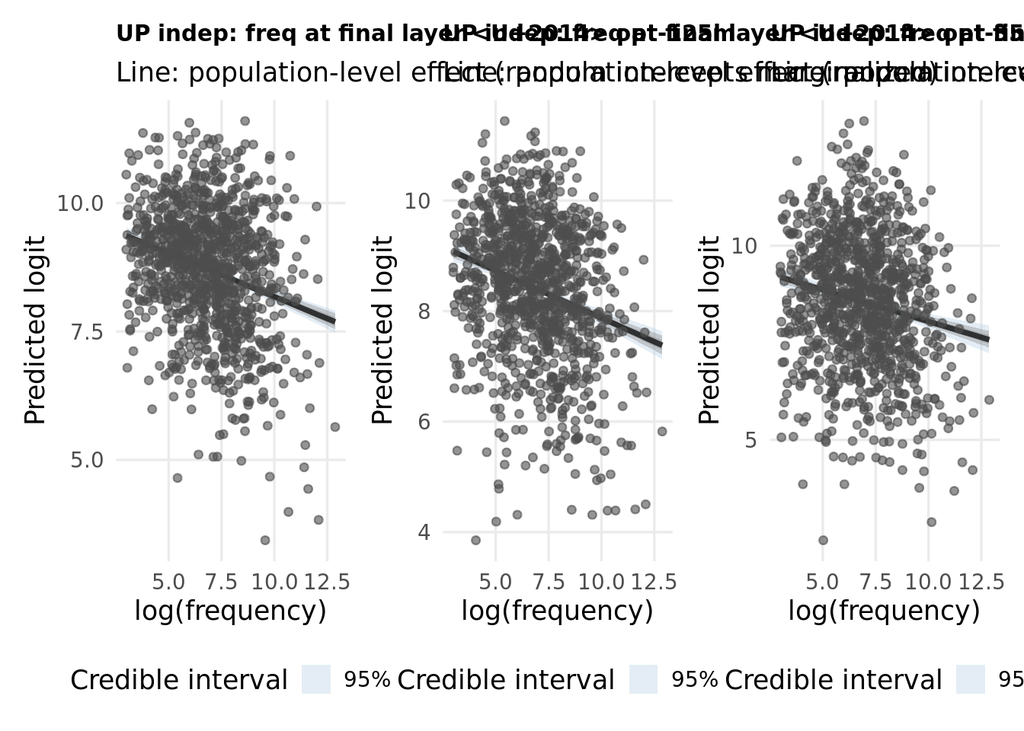

```r
# Final layer brms plots — one panel per model size
blm_wrap_plots(lapply(BLM_TAGS, function(tag) {
  plot_final_layer(blm_freq_indep_final_models[[tag]],
                   blm_indep_final %>% filter(model == tag),
                   paste0("UP indep: freq at final layer — ", tag))
}))
```

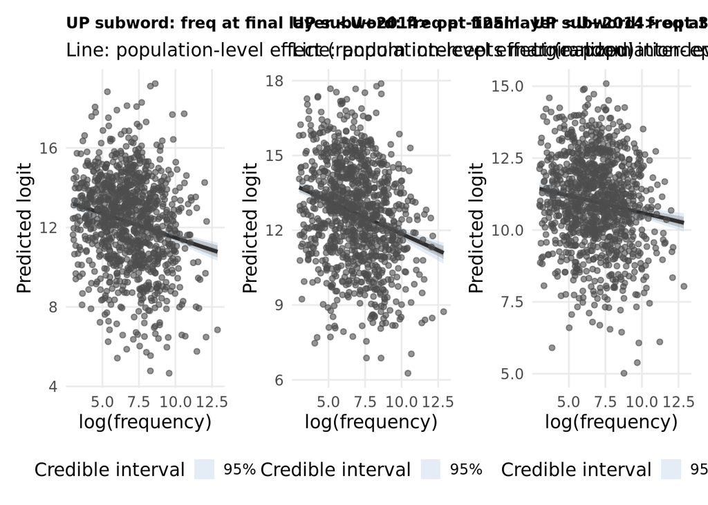

```r
blm_wrap_plots(lapply(BLM_TAGS, function(tag) {
  plot_final_layer(blm_freq_sub_final_models[[tag]],
                   blm_sub_final %>% filter(model == tag),
                   paste0("UP subword: freq at final layer — ", tag))
}))
```

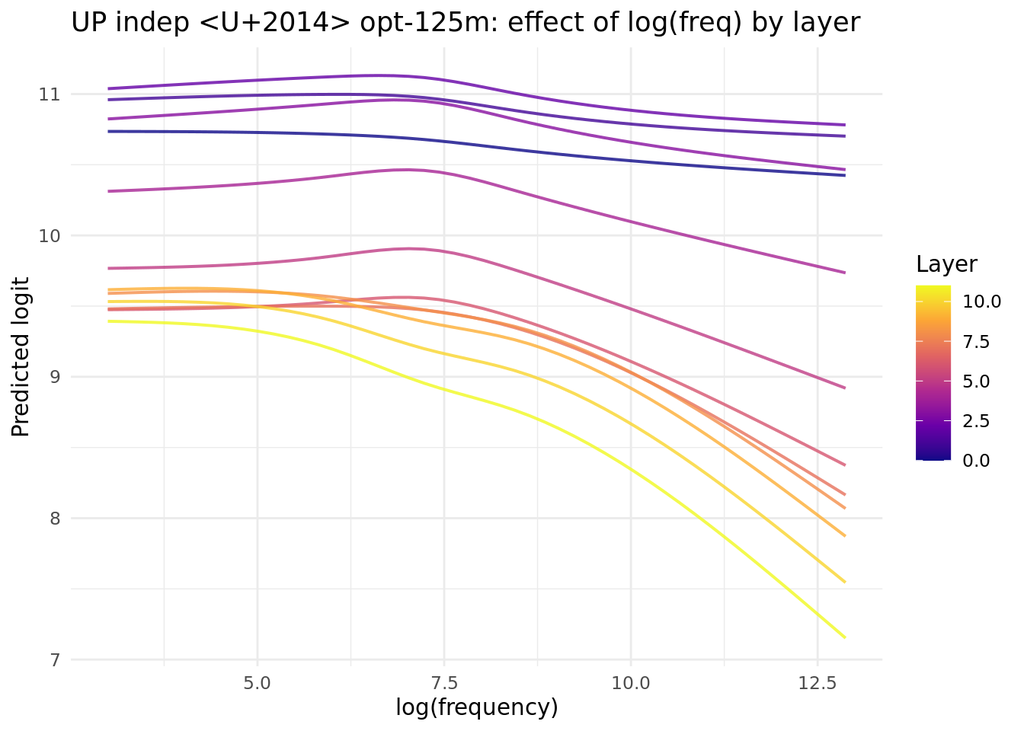

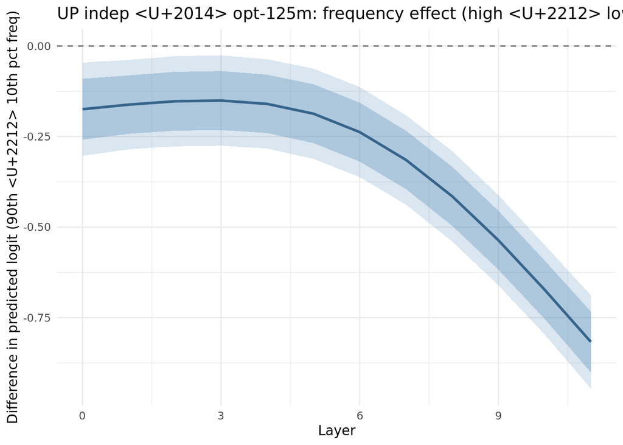

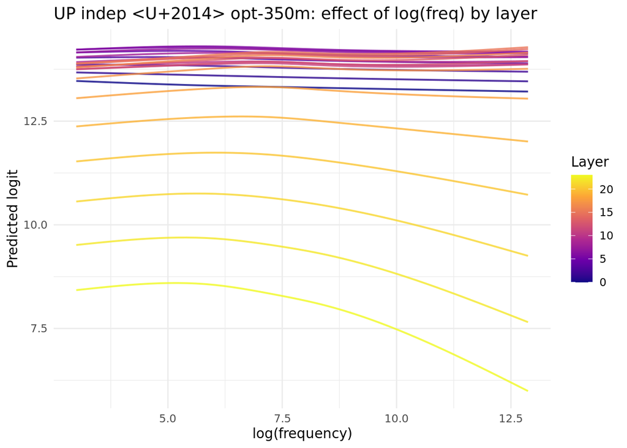

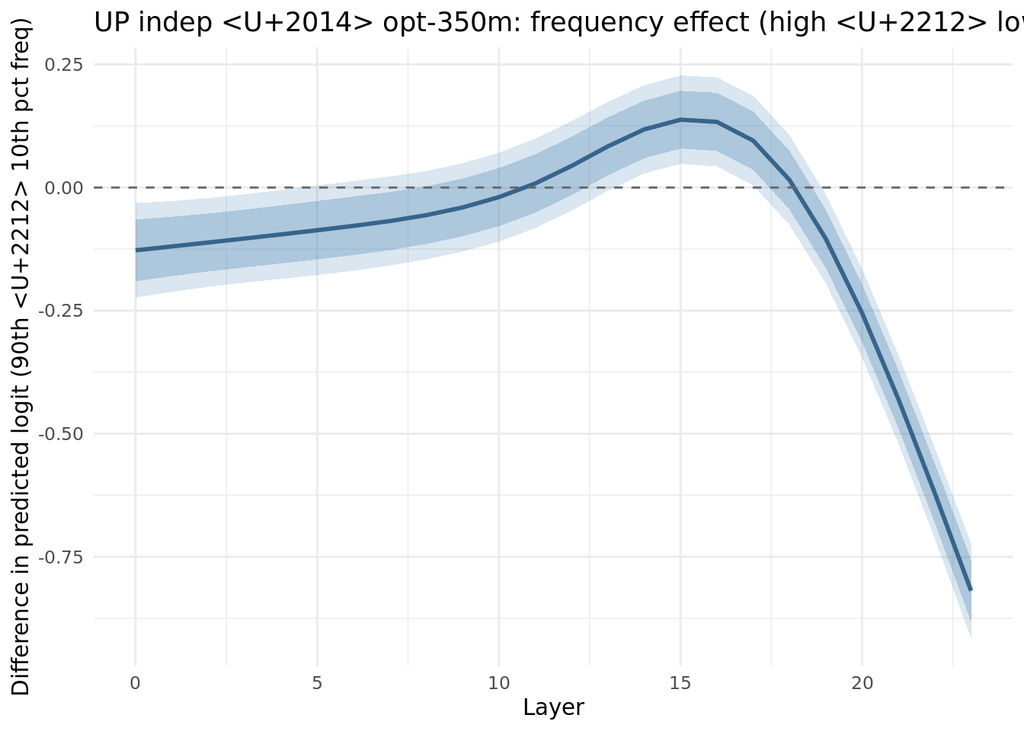

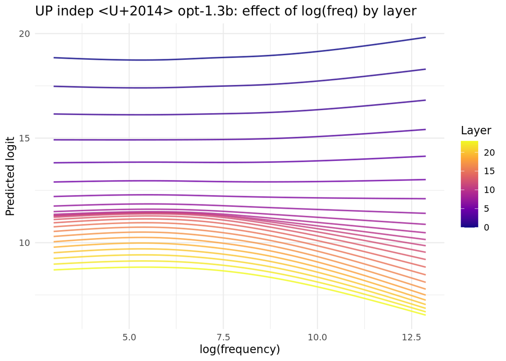

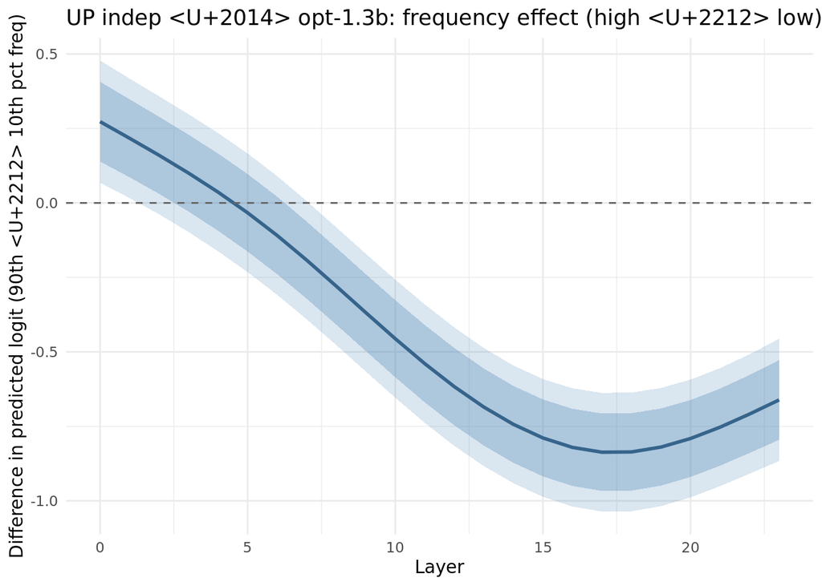

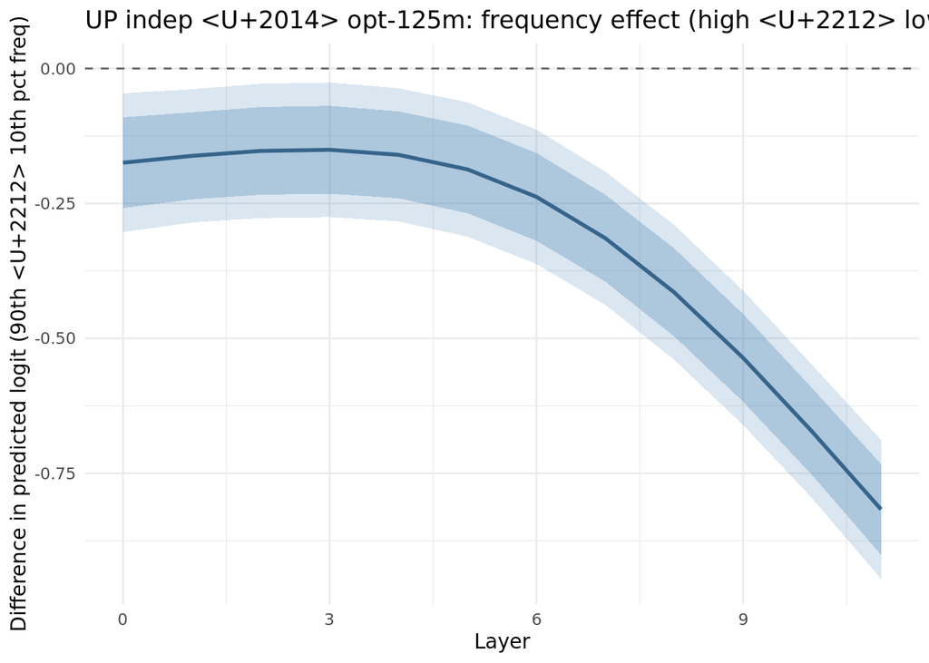

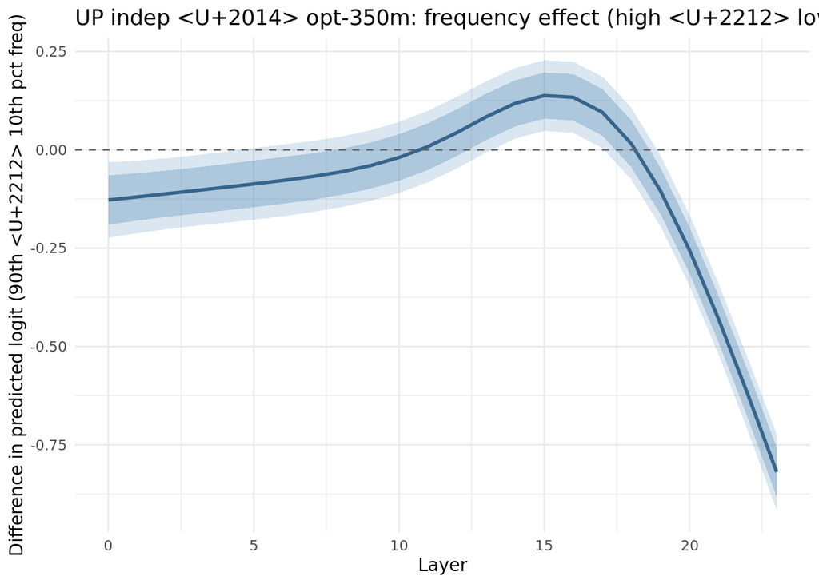

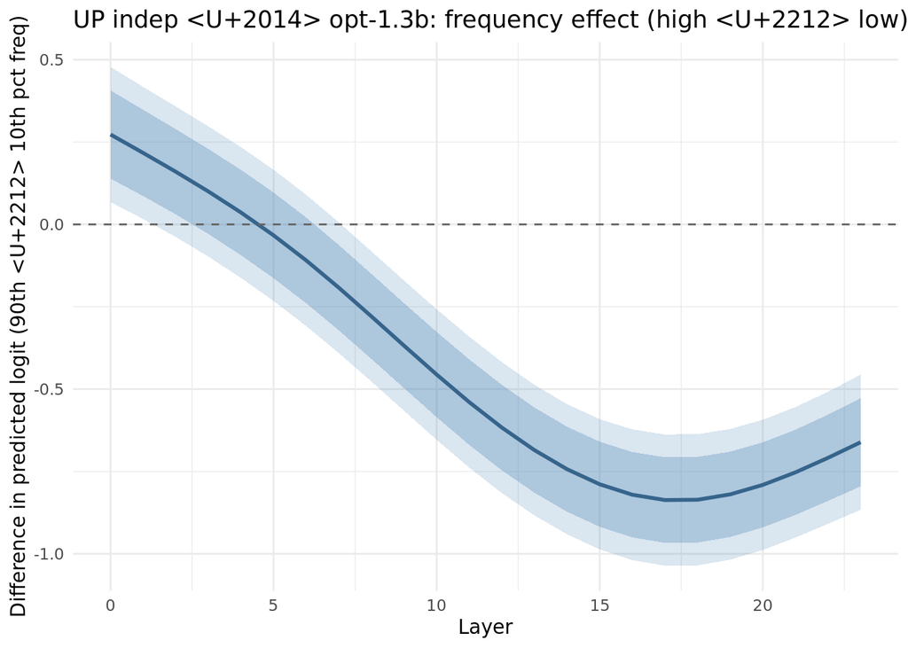

```r
# Frequency × layer spaghetti + diff plots per model
lapply(BLM_TAGS, function(tag) {
  plots = plot_freq_by_layer_mgcv(blm_freq_layer_indep_models[[tag]],
                                   blm_indep %>% filter(model == tag),
                                   paste0("UP indep — ", tag),
                                   n_layers = BLM_N_LAYERS[[tag]])
  print(plots$spaghetti); print(plots$diff)
})
```

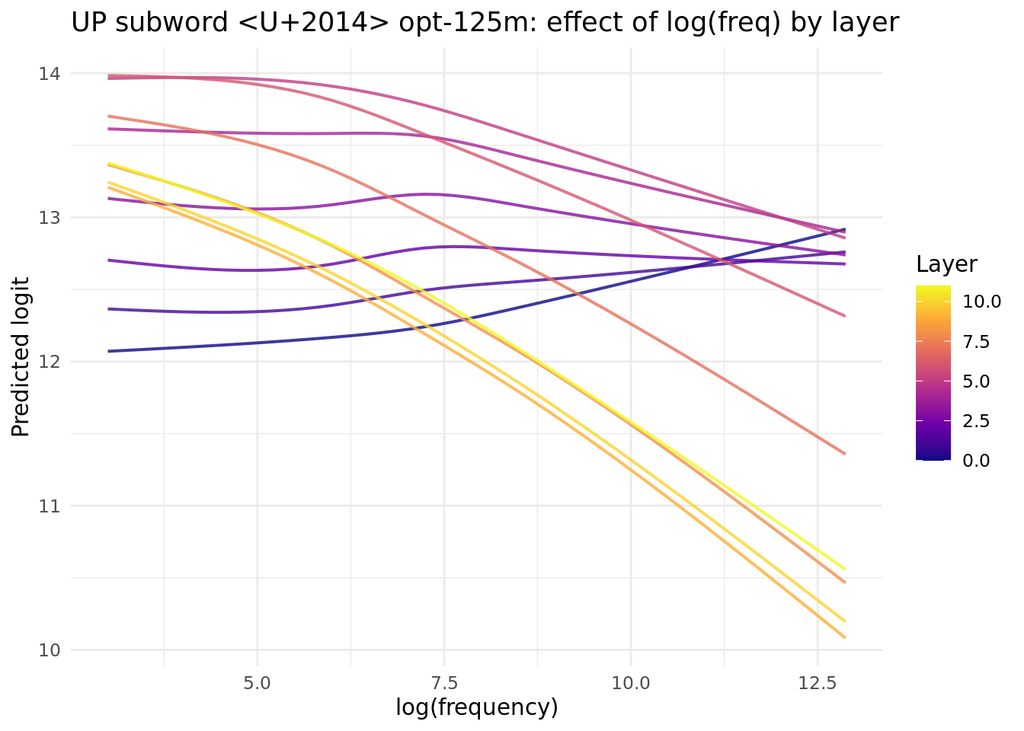

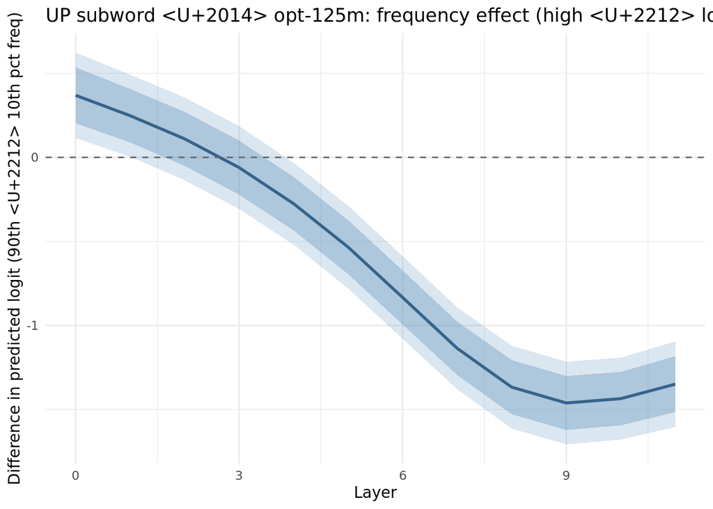

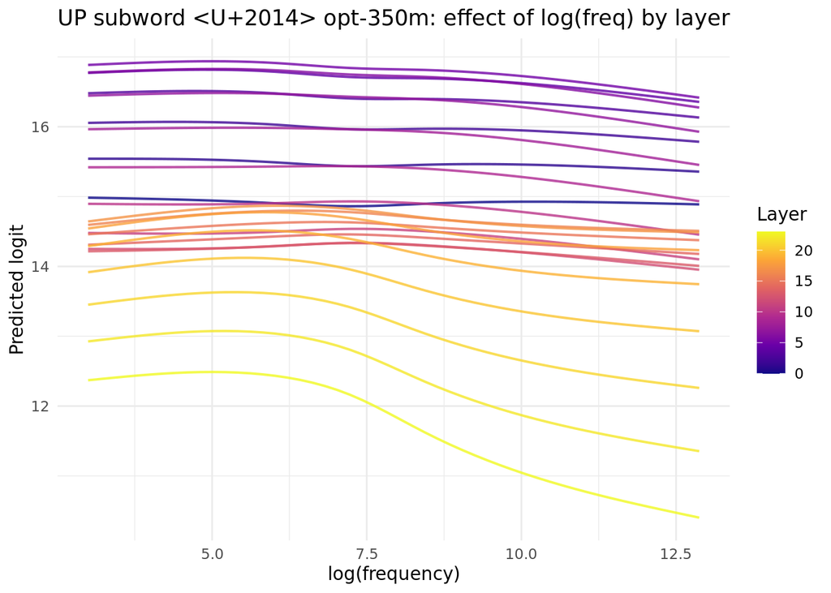

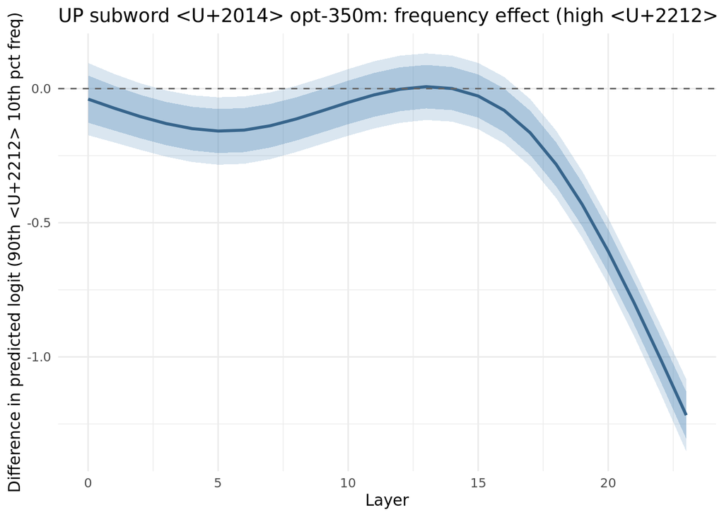

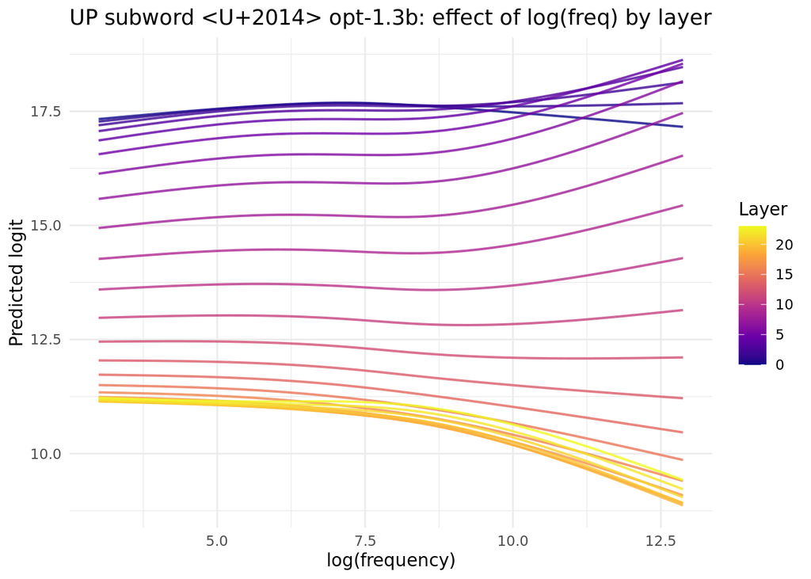

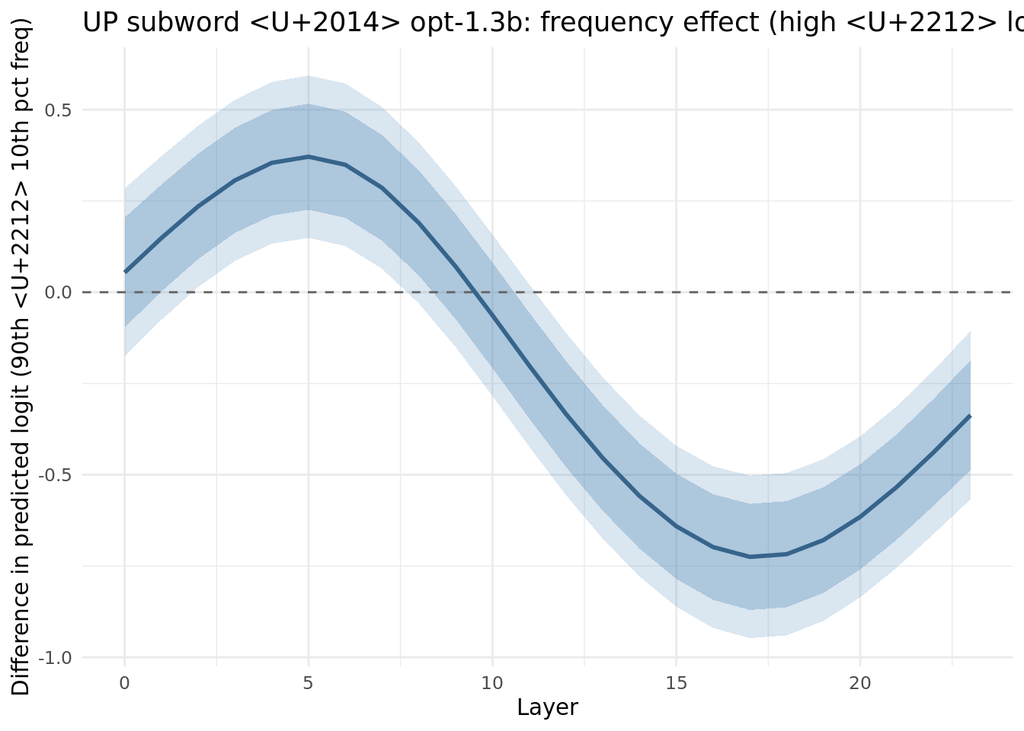

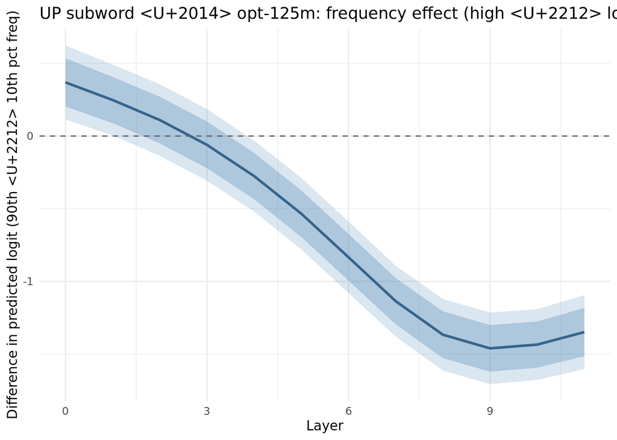

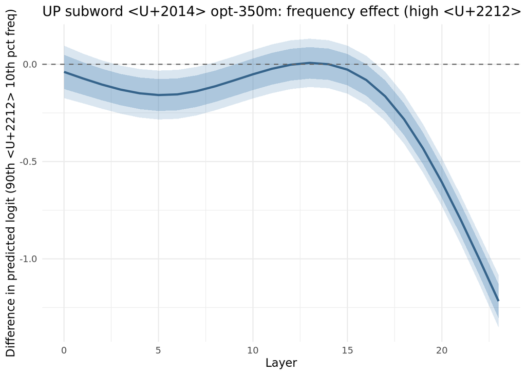

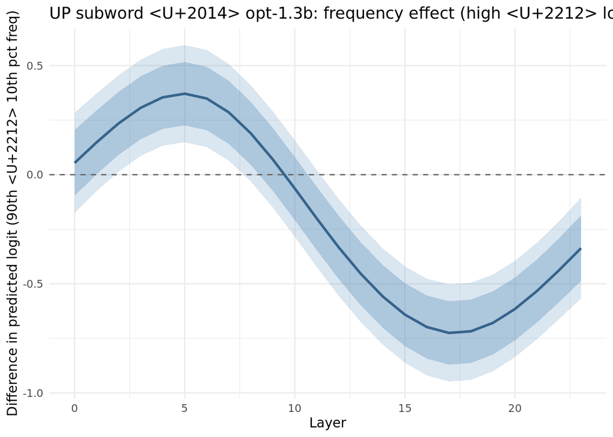

```r
lapply(BLM_TAGS, function(tag) {
  plots = plot_freq_by_layer_mgcv(blm_freq_layer_sub_models[[tag]],
                                   blm_sub %>% filter(model == tag),
                                   paste0("UP subword — ", tag),
                                   n_layers = BLM_N_LAYERS[[tag]])
  print(plots$spaghetti); print(plots$diff)
})
```

## BabyLM — Predictability (FTP = P(up|V))

```r
blm_indep_final_ftp = blm_indep_final %>% filter(!is.na(log_ftp)) %>%
  group_by(model) %>%
  mutate(c_log_freq = c(scale(log_freq)), c_log_ftp = c(scale(log_ftp))) %>% ungroup()
blm_sub_final_ftp   = blm_sub_final   %>% filter(!is.na(log_ftp)) %>%
  group_by(model) %>%
  mutate(c_log_freq = c(scale(log_freq)), c_log_ftp = c(scale(log_ftp))) %>% ungroup()
blm_indep_first_ftp = blm_indep_first %>% filter(!is.na(log_ftp)) %>%
  group_by(model) %>%
  mutate(c_log_freq = c(scale(log_freq)), c_log_ftp = c(scale(log_ftp))) %>% ungroup()
blm_sub_first_ftp   = blm_sub_first   %>% filter(!is.na(log_ftp)) %>%
  group_by(model) %>%
  mutate(c_log_freq = c(scale(log_freq)), c_log_ftp = c(scale(log_ftp))) %>% ungroup()
blm_indep_ftp       = blm_indep       %>% filter(!is.na(log_ftp))
blm_subword_ftp     = blm_sub         %>% filter(!is.na(log_ftp))
```

### FTP at the final layer — per model (brms)

```r
blm_ftp_indep_final_models = lapply(setNames(BLM_TAGS, BLM_TAGS), function(tag) {
  brm(
    formula = logit ~ log_ftp + (1 | verb_up),
    data    = blm_indep_final_ftp %>% filter(model == tag),
    prior   = priors,
    iter = 6000, warmup = 3000, chains = 4, cores = 4, seed = 964,
    file    = blm_brms_path(paste0("model_ftp_indep_final_", blm_slug(tag)))
  )
})
blm_ftp_sub_final_models = lapply(setNames(BLM_TAGS, BLM_TAGS), function(tag) {
  brm(
    formula = logit ~ log_ftp + (1 | verb_up),
    data    = blm_sub_final_ftp %>% filter(model == tag),
    prior   = priors,
    iter = 6000, warmup = 3000, chains = 4, cores = 4, seed = 964,
    file    = blm_brms_path(paste0("model_ftp_sub_final_", blm_slug(tag)))
  )
})
lapply(blm_ftp_indep_final_models, summary)
```

```
## $`opt-125m`
##  Family: gaussian
##   Links: mu = identity
## Formula: logit ~ log_ftp + (1 | verb_up)
##    Data: blm_indep_final_ftp %>% filter(model == tag) (Number of observations: 20541)
##   Draws: 4 chains, each with iter = 6000; warmup = 3000; thin = 1;
##          total post-warmup draws = 12000
##
## Multilevel Hyperparameters:
## ~verb_up (Number of levels: 1039)
##               Estimate Est.Error l-95% CI u-95% CI Rhat Bulk_ESS Tail_ESS
## sd(Intercept)     1.19      0.03     1.14     1.25 1.00     1405     2529
##
## Regression Coefficients:
##           Estimate Est.Error l-95% CI u-95% CI Rhat Bulk_ESS Tail_ESS
## Intercept     8.55      0.08     8.39     8.72 1.01     1015     1911
## log_ftp      -0.05      0.02    -0.09    -0.00 1.01     1003     1802
##
## Further Distributional Parameters:
##       Estimate Est.Error l-95% CI u-95% CI Rhat Bulk_ESS Tail_ESS
## sigma     1.43      0.01     1.42     1.45 1.00    14392     9283
##
## Draws were sampled using sampling(NUTS). For each parameter, Bulk_ESS
## and Tail_ESS are effective sample size measures, and Rhat is the potential
## scale reduction factor on split chains (at convergence, Rhat = 1).
##
## $`opt-350m`
##  Family: gaussian
##   Links: mu = identity
## Formula: logit ~ log_ftp + (1 | verb_up)
##    Data: blm_indep_final_ftp %>% filter(model == tag) (Number of observations: 20541)
##   Draws: 4 chains, each with iter = 6000; warmup = 3000; thin = 1;
##          total post-warmup draws = 12000
##
## Multilevel Hyperparameters:
## ~verb_up (Number of levels: 1039)
##               Estimate Est.Error l-95% CI u-95% CI Rhat Bulk_ESS Tail_ESS
## sd(Intercept)     1.24      0.03     1.18     1.30 1.00     1625     2305
##
## Regression Coefficients:
```

[output cut: 22 more lines]

```
##               Estimate Est.Error l-95% CI u-95% CI Rhat Bulk_ESS Tail_ESS
## sd(Intercept)     1.63      0.04     1.55     1.70 1.00     1677     3558
##
## Regression Coefficients:
##           Estimate Est.Error l-95% CI u-95% CI Rhat Bulk_ESS Tail_ESS
## Intercept     8.15      0.12     7.93     8.37 1.00     1071     2344
## log_ftp      -0.12      0.03    -0.17    -0.06 1.00     1019     1781
##
## Further Distributional Parameters:
##       Estimate Est.Error l-95% CI u-95% CI Rhat Bulk_ESS Tail_ESS
## sigma     2.06      0.01     2.04     2.08 1.00    15712     8326
##
## Draws were sampled using sampling(NUTS). For each parameter, Bulk_ESS
## and Tail_ESS are effective sample size measures, and Rhat is the potential
## scale reduction factor on split chains (at convergence, Rhat = 1).
```

```r
lapply(blm_ftp_sub_final_models, summary)
```

```
## $`opt-125m`
##  Family: gaussian
##   Links: mu = identity
## Formula: logit ~ log_ftp + (1 | verb_up)
##    Data: blm_sub_final_ftp %>% filter(model == tag) (Number of observations: 20541)
##   Draws: 4 chains, each with iter = 6000; warmup = 3000; thin = 1;
##          total post-warmup draws = 12000
##
## Multilevel Hyperparameters:
## ~verb_up (Number of levels: 1039)
##               Estimate Est.Error l-95% CI u-95% CI Rhat Bulk_ESS Tail_ESS
## sd(Intercept)     2.22      0.05     2.12     2.32 1.00     1419     2861
##
## Regression Coefficients:
##           Estimate Est.Error l-95% CI u-95% CI Rhat Bulk_ESS Tail_ESS
## Intercept    12.41      0.16    12.11    12.72 1.00      885     1582
## log_ftp       0.05      0.04    -0.03     0.13 1.00      894     1540
##
## Further Distributional Parameters:
##       Estimate Est.Error l-95% CI u-95% CI Rhat Bulk_ESS Tail_ESS
## sigma     2.91      0.01     2.88     2.94 1.00    13651     8534
##
## Draws were sampled using sampling(NUTS). For each parameter, Bulk_ESS
## and Tail_ESS are effective sample size measures, and Rhat is the potential
## scale reduction factor on split chains (at convergence, Rhat = 1).
##
## $`opt-350m`
##  Family: gaussian
##   Links: mu = identity
## Formula: logit ~ log_ftp + (1 | verb_up)
##    Data: blm_sub_final_ftp %>% filter(model == tag) (Number of observations: 20541)
##   Draws: 4 chains, each with iter = 6000; warmup = 3000; thin = 1;
##          total post-warmup draws = 12000
##
## Multilevel Hyperparameters:
## ~verb_up (Number of levels: 1039)
##               Estimate Est.Error l-95% CI u-95% CI Rhat Bulk_ESS Tail_ESS
## sd(Intercept)     1.93      0.05     1.84     2.03 1.00     1879     3682
##
## Regression Coefficients:
```

[output cut: 22 more lines]

```
##               Estimate Est.Error l-95% CI u-95% CI Rhat Bulk_ESS Tail_ESS
## sd(Intercept)     1.46      0.04     1.39     1.54 1.00     2641     5321
##
## Regression Coefficients:
##           Estimate Est.Error l-95% CI u-95% CI Rhat Bulk_ESS Tail_ESS
## Intercept    10.80      0.11    10.58    11.01 1.00     1893     3593
## log_ftp      -0.05      0.03    -0.10     0.00 1.00     1953     3637
##
## Further Distributional Parameters:
##       Estimate Est.Error l-95% CI u-95% CI Rhat Bulk_ESS Tail_ESS
## sigma     2.77      0.01     2.75     2.80 1.00    15283     8398
##
## Draws were sampled using sampling(NUTS). For each parameter, Bulk_ESS
## and Tail_ESS are effective sample size measures, and Rhat is the potential
## scale reduction factor on split chains (at convergence, Rhat = 1).
```

### FTP at the first layer — per model (brms)

```r
blm_ftp_indep_first_models = lapply(setNames(BLM_TAGS, BLM_TAGS), function(tag) {
  brm(
    formula = logit ~ log_ftp + (1 | verb_up),
    data    = blm_indep_first_ftp %>% filter(model == tag),
    prior   = priors,
    iter = 6000, warmup = 3000, chains = 4, cores = 4, seed = 964,
    file    = blm_brms_path(paste0("model_ftp_indep_first_", blm_slug(tag)))
  )
})
blm_ftp_sub_first_models = lapply(setNames(BLM_TAGS, BLM_TAGS), function(tag) {
  brm(
    formula = logit ~ log_ftp + (1 | verb_up),
    data    = blm_sub_first_ftp %>% filter(model == tag),
    prior   = priors,
    iter = 6000, warmup = 3000, chains = 4, cores = 4, seed = 964,
    file    = blm_brms_path(paste0("model_ftp_sub_first_", blm_slug(tag)))
  )
})
lapply(blm_ftp_indep_first_models, summary)
```

```
## $`opt-125m`
##  Family: gaussian
##   Links: mu = identity
## Formula: logit ~ log_ftp + (1 | verb_up)
##    Data: blm_indep_first_ftp %>% filter(model == tag) (Number of observations: 20541)
##   Draws: 4 chains, each with iter = 6000; warmup = 3000; thin = 1;
##          total post-warmup draws = 12000
##
## Multilevel Hyperparameters:
## ~verb_up (Number of levels: 1039)
##               Estimate Est.Error l-95% CI u-95% CI Rhat Bulk_ESS Tail_ESS
## sd(Intercept)     0.63      0.02     0.60     0.66 1.00     2179     4424
##
## Regression Coefficients:
##           Estimate Est.Error l-95% CI u-95% CI Rhat Bulk_ESS Tail_ESS
## Intercept    10.72      0.05    10.63    10.81 1.00     1372     2844
## log_ftp      -0.01      0.01    -0.03     0.01 1.00     1361     2688
##
## Further Distributional Parameters:
##       Estimate Est.Error l-95% CI u-95% CI Rhat Bulk_ESS Tail_ESS
## sigma     1.12      0.01     1.11     1.13 1.00    13418     9444
##
## Draws were sampled using sampling(NUTS). For each parameter, Bulk_ESS
## and Tail_ESS are effective sample size measures, and Rhat is the potential
## scale reduction factor on split chains (at convergence, Rhat = 1).
##
## $`opt-350m`
##  Family: gaussian
##   Links: mu = identity
## Formula: logit ~ log_ftp + (1 | verb_up)
##    Data: blm_indep_first_ftp %>% filter(model == tag) (Number of observations: 20541)
##   Draws: 4 chains, each with iter = 6000; warmup = 3000; thin = 1;
##          total post-warmup draws = 12000
##
## Multilevel Hyperparameters:
## ~verb_up (Number of levels: 1039)
##               Estimate Est.Error l-95% CI u-95% CI Rhat Bulk_ESS Tail_ESS
## sd(Intercept)     0.17      0.01     0.15     0.18 1.00     4158     6355
##
## Regression Coefficients:
```

[output cut: 22 more lines]

```
##               Estimate Est.Error l-95% CI u-95% CI Rhat Bulk_ESS Tail_ESS
## sd(Intercept)     0.61      0.04     0.54     0.68 1.00     4511     6971
##
## Regression Coefficients:
##           Estimate Est.Error l-95% CI u-95% CI Rhat Bulk_ESS Tail_ESS
## Intercept    17.98      0.07    17.84    18.11 1.00     8076     7667
## log_ftp      -0.02      0.02    -0.05     0.01 1.00     7776     7565
##
## Further Distributional Parameters:
##       Estimate Est.Error l-95% CI u-95% CI Rhat Bulk_ESS Tail_ESS
## sigma     3.44      0.02     3.41     3.48 1.00    15142     8435
##
## Draws were sampled using sampling(NUTS). For each parameter, Bulk_ESS
## and Tail_ESS are effective sample size measures, and Rhat is the potential
## scale reduction factor on split chains (at convergence, Rhat = 1).
```

```r
lapply(blm_ftp_sub_first_models, summary)
```

```
## $`opt-125m`
##  Family: gaussian
##   Links: mu = identity
## Formula: logit ~ log_ftp + (1 | verb_up)
##    Data: blm_sub_first_ftp %>% filter(model == tag) (Number of observations: 20541)
##   Draws: 4 chains, each with iter = 6000; warmup = 3000; thin = 1;
##          total post-warmup draws = 12000
##
## Multilevel Hyperparameters:
## ~verb_up (Number of levels: 1039)
##               Estimate Est.Error l-95% CI u-95% CI Rhat Bulk_ESS Tail_ESS
## sd(Intercept)     1.34      0.03     1.28     1.41 1.00     2185     4193
##
## Regression Coefficients:
##           Estimate Est.Error l-95% CI u-95% CI Rhat Bulk_ESS Tail_ESS
## Intercept    12.05      0.10    11.86    12.24 1.00     1238     2589
## log_ftp      -0.10      0.02    -0.15    -0.05 1.00     1222     2599
##
## Further Distributional Parameters:
##       Estimate Est.Error l-95% CI u-95% CI Rhat Bulk_ESS Tail_ESS
## sigma     2.17      0.01     2.15     2.19 1.00    14054     8310
##
## Draws were sampled using sampling(NUTS). For each parameter, Bulk_ESS
## and Tail_ESS are effective sample size measures, and Rhat is the potential
## scale reduction factor on split chains (at convergence, Rhat = 1).
##
## $`opt-350m`
##  Family: gaussian
##   Links: mu = identity
## Formula: logit ~ log_ftp + (1 | verb_up)
##    Data: blm_sub_first_ftp %>% filter(model == tag) (Number of observations: 20541)
##   Draws: 4 chains, each with iter = 6000; warmup = 3000; thin = 1;
##          total post-warmup draws = 12000
##
## Multilevel Hyperparameters:
## ~verb_up (Number of levels: 1039)
##               Estimate Est.Error l-95% CI u-95% CI Rhat Bulk_ESS Tail_ESS
## sd(Intercept)     0.31      0.02     0.27     0.35 1.00     4211     5929
##
## Regression Coefficients:
```

[output cut: 22 more lines]

```
##               Estimate Est.Error l-95% CI u-95% CI Rhat Bulk_ESS Tail_ESS
## sd(Intercept)     1.00      0.03     0.93     1.06 1.00     4167     6659
##
## Regression Coefficients:
##           Estimate Est.Error l-95% CI u-95% CI Rhat Bulk_ESS Tail_ESS
## Intercept    17.47      0.08    17.31    17.63 1.00     4147     6752
## log_ftp      -0.02      0.02    -0.06     0.02 1.00     3967     6215
##
## Further Distributional Parameters:
##       Estimate Est.Error l-95% CI u-95% CI Rhat Bulk_ESS Tail_ESS
## sigma     3.14      0.02     3.11     3.17 1.00    13360     9297
##
## Draws were sampled using sampling(NUTS). For each parameter, Bulk_ESS
## and Tail_ESS are effective sample size measures, and Rhat is the potential
## scale reduction factor on split chains (at convergence, Rhat = 1).
```

### FTP at the final layer — per model (bam — non-linear)

```r
set.seed(964)
blm_bam_ftp_indep_final_models = lapply(setNames(BLM_TAGS, BLM_TAGS), function(tag) {
  blm_cache_bam(paste0("bam_ftp_indep_final_", blm_slug(tag)), function() {
    bam(logit ~ s(log_ftp) + s(verb_up, bs = 're'),
        data = blm_indep_final_ftp %>% filter(model == tag), method = 'fREML', discrete = TRUE)
  })
})
blm_bam_ftp_sub_final_models = lapply(setNames(BLM_TAGS, BLM_TAGS), function(tag) {
  blm_cache_bam(paste0("bam_ftp_sub_final_", blm_slug(tag)), function() {
    bam(logit ~ s(log_ftp) + s(verb_up, bs = 're'),
        data = blm_sub_final_ftp %>% filter(model == tag), method = 'fREML', discrete = TRUE)
  })
})
lapply(blm_bam_ftp_indep_final_models, summary)
```

```
## $`opt-125m`
##
## Family: gaussian
## Link function: identity
##
## Formula:
## logit ~ s(log_ftp) + s(verb_up, bs = "re")
##
## Parametric coefficients:
##             Estimate Std. Error t value Pr(>|t|)
## (Intercept)  8.77870    0.03921   223.9   <2e-16 ***
## ---
## Signif. codes:  0 '***' 0.001 '**' 0.01 '*' 0.05 '.' 0.1 ' ' 1
##
## Approximate significance of smooth terms:
##                edf   Ref.df     F p-value
## s(log_ftp)   5.267    5.351 10.09  <2e-16 ***
## s(verb_up) 958.870 1037.000 13.77  <2e-16 ***
## ---
## Signif. codes:  0 '***' 0.001 '**' 0.01 '*' 0.05 '.' 0.1 ' ' 1
##
## R-sq.(adj) =   0.41   Deviance explained = 43.8%
## fREML =  37895  Scale est. = 2.0487    n = 20541
##
## $`opt-350m`
##
## Family: gaussian
## Link function: identity
##
## Formula:
## logit ~ s(log_ftp) + s(verb_up, bs = "re")
##
## Parametric coefficients:
##             Estimate Std. Error t value Pr(>|t|)
## (Intercept)  8.47260    0.04072   208.1   <2e-16 ***
## ---
## Signif. codes:  0 '***' 0.001 '**' 0.01 '*' 0.05 '.' 0.1 ' ' 1
##
## Approximate significance of smooth terms:
##                edf   Ref.df      F  p-value
```

[output cut: 16 more lines]

```
## Parametric coefficients:
##             Estimate Std. Error t value Pr(>|t|)
## (Intercept)  8.68922    0.05353   162.3   <2e-16 ***
## ---
## Signif. codes:  0 '***' 0.001 '**' 0.01 '*' 0.05 '.' 0.1 ' ' 1
##
## Approximate significance of smooth terms:
##                edf   Ref.df     F p-value
## s(log_ftp)   4.619    4.708 15.84  <2e-16 ***
## s(verb_up) 951.385 1037.000 12.08  <2e-16 ***
## ---
## Signif. codes:  0 '***' 0.001 '**' 0.01 '*' 0.05 '.' 0.1 ' ' 1
##
## R-sq.(adj) =  0.388   Deviance explained = 41.7%
## fREML =  45270  Scale est. = 4.2236    n = 20541
```

```r
lapply(blm_bam_ftp_sub_final_models, summary)
```

```
## $`opt-125m`
##
## Family: gaussian
## Link function: identity
##
## Formula:
## logit ~ s(log_ftp) + s(verb_up, bs = "re")
##
## Parametric coefficients:
##             Estimate Std. Error t value Pr(>|t|)
## (Intercept) 12.36486    0.07476   165.4   <2e-16 ***
## ---
## Signif. codes:  0 '***' 0.001 '**' 0.01 '*' 0.05 '.' 0.1 ' ' 1
##
## Approximate significance of smooth terms:
##                edf   Ref.df      F  p-value
## s(log_ftp)   4.281    4.371  7.307 3.68e-06 ***
## s(verb_up) 947.677 1037.000 11.527  < 2e-16 ***
## ---
## Signif. codes:  0 '***' 0.001 '**' 0.01 '*' 0.05 '.' 0.1 ' ' 1
##
## R-sq.(adj) =  0.367   Deviance explained = 39.6%
## fREML =  52397  Scale est. = 8.4743    n = 20541
##
## $`opt-350m`
##
## Family: gaussian
## Link function: identity
##
## Formula:
## logit ~ s(log_ftp) + s(verb_up, bs = "re")
##
## Parametric coefficients:
##             Estimate Std. Error t value Pr(>|t|)
## (Intercept) 12.75591    0.06546   194.9   <2e-16 ***
## ---
## Signif. codes:  0 '***' 0.001 '**' 0.01 '*' 0.05 '.' 0.1 ' ' 1
##
## Approximate significance of smooth terms:
##                edf   Ref.df     F  p-value
```

[output cut: 16 more lines]

```
## Parametric coefficients:
##             Estimate Std. Error t value Pr(>|t|)
## (Intercept) 11.03726    0.05079   217.3   <2e-16 ***
## ---
## Signif. codes:  0 '***' 0.001 '**' 0.01 '*' 0.05 '.' 0.1 ' ' 1
##
## Approximate significance of smooth terms:
##                edf   Ref.df     F  p-value
## s(log_ftp)   3.778    3.936 7.712 6.38e-06 ***
## s(verb_up) 870.288 1037.000 5.472  < 2e-16 ***
## ---
## Signif. codes:  0 '***' 0.001 '**' 0.01 '*' 0.05 '.' 0.1 ' ' 1
##
## R-sq.(adj) =  0.218   Deviance explained = 25.1%
## fREML =  51074  Scale est. = 7.6971    n = 20541
```

### FTP × layer — per model (mgcv)

```r
set.seed(964)
blm_ftp_layer_indep_models = lapply(setNames(BLM_TAGS, BLM_TAGS), function(tag) {
  blm_cache_bam(paste0("model_ftp_layer_indep_", blm_slug(tag)), function() {
    bam(logit ~ te(log_ftp, layer) + s(verb_up, bs = 're'),
        data = blm_indep_ftp %>% filter(model == tag), method = 'fREML', discrete = TRUE)
  })
})
blm_ftp_layer_sub_models = lapply(setNames(BLM_TAGS, BLM_TAGS), function(tag) {
  blm_cache_bam(paste0("model_ftp_layer_sub_", blm_slug(tag)), function() {
    bam(logit ~ te(log_ftp, layer) + s(verb_up, bs = 're'),
        data = blm_subword_ftp %>% filter(model == tag), method = 'fREML', discrete = TRUE)
  })
})
lapply(blm_ftp_layer_indep_models, summary)
```

```
## $`opt-125m`
##
## Family: gaussian
## Link function: identity
##
## Formula:
## logit ~ te(log_ftp, layer) + s(verb_up, bs = "re")
##
## Parametric coefficients:
##             Estimate Std. Error t value Pr(>|t|)
## (Intercept)  9.93767    0.02498   397.8   <2e-16 ***
## ---
## Signif. codes:  0 '***' 0.001 '**' 0.01 '*' 0.05 '.' 0.1 ' ' 1
##
## Approximate significance of smooth terms:
##                       edf  Ref.df      F p-value
## te(log_ftp,layer)   22.52   22.78 3421.2  <2e-16 ***
## s(verb_up)        1022.63 1037.00  191.9  <2e-16 ***
## ---
## Signif. codes:  0 '***' 0.001 '**' 0.01 '*' 0.05 '.' 0.1 ' ' 1
##
## R-sq.(adj) =  0.398   Deviance explained = 40.1%
## fREML = 4.1761e+05  Scale est. = 1.7014    n = 246492
##
## $`opt-350m`
##
## Family: gaussian
## Link function: identity
##
## Formula:
## logit ~ te(log_ftp, layer) + s(verb_up, bs = "re")
##
## Parametric coefficients:
##             Estimate Std. Error t value Pr(>|t|)
## (Intercept) 13.20230    0.01777   743.2   <2e-16 ***
## ---
## Signif. codes:  0 '***' 0.001 '**' 0.01 '*' 0.05 '.' 0.1 ' ' 1
##
## Approximate significance of smooth terms:
##                       edf  Ref.df     F p-value
```

[output cut: 16 more lines]

```
## Parametric coefficients:
##             Estimate Std. Error t value Pr(>|t|)
## (Intercept)  11.7595     0.0397   296.2   <2e-16 ***
## ---
## Signif. codes:  0 '***' 0.001 '**' 0.01 '*' 0.05 '.' 0.1 ' ' 1
##
## Approximate significance of smooth terms:
##                       edf  Ref.df       F p-value
## te(log_ftp,layer)   22.47   22.68 27285.9  <2e-16 ***
## s(verb_up)        1027.25 1037.00   483.3  <2e-16 ***
## ---
## Signif. codes:  0 '***' 0.001 '**' 0.01 '*' 0.05 '.' 0.1 ' ' 1
##
## R-sq.(adj) =  0.607   Deviance explained = 60.8%
## fREML = 1.1229e+06  Scale est. = 5.5131    n = 492984
```

```r
lapply(blm_ftp_layer_sub_models, summary)
```

```
## $`opt-125m`
##
## Family: gaussian
## Link function: identity
##
## Formula:
## logit ~ te(log_ftp, layer) + s(verb_up, bs = "re")
##
## Parametric coefficients:
##             Estimate Std. Error t value Pr(>|t|)
## (Intercept) 12.87620    0.05107   252.1   <2e-16 ***
## ---
## Signif. codes:  0 '***' 0.001 '**' 0.01 '*' 0.05 '.' 0.1 ' ' 1
##
## Approximate significance of smooth terms:
##                       edf  Ref.df      F p-value
## te(log_ftp,layer)   22.15   22.63 517.34  <2e-16 ***
## s(verb_up)        1021.96 1037.00  97.07  <2e-16 ***
## ---
## Signif. codes:  0 '***' 0.001 '**' 0.01 '*' 0.05 '.' 0.1 ' ' 1
##
## R-sq.(adj) =  0.277   Deviance explained = 28.1%
## fREML = 6.0339e+05  Scale est. = 7.6839    n = 246492
##
## $`opt-350m`
##
## Family: gaussian
## Link function: identity
##
## Formula:
## logit ~ te(log_ftp, layer) + s(verb_up, bs = "re")
##
## Parametric coefficients:
##             Estimate Std. Error t value Pr(>|t|)
## (Intercept) 14.95062    0.02415   619.1   <2e-16 ***
## ---
## Signif. codes:  0 '***' 0.001 '**' 0.01 '*' 0.05 '.' 0.1 ' ' 1
##
## Approximate significance of smooth terms:
##                      edf  Ref.df      F p-value
```

[output cut: 16 more lines]

```
## Parametric coefficients:
##             Estimate Std. Error t value Pr(>|t|)
## (Intercept) 13.62363    0.04482   303.9   <2e-16 ***
## ---
## Signif. codes:  0 '***' 0.001 '**' 0.01 '*' 0.05 '.' 0.1 ' ' 1
##
## Approximate significance of smooth terms:
##                       edf  Ref.df       F p-value
## te(log_ftp,layer)   21.51   22.06 20339.5  <2e-16 ***
## s(verb_up)        1026.63 1037.00   329.2  <2e-16 ***
## ---
## Signif. codes:  0 '***' 0.001 '**' 0.01 '*' 0.05 '.' 0.1 ' ' 1
##
## R-sq.(adj) =  0.535   Deviance explained = 53.6%
## fREML = 1.2208e+06  Scale est. = 8.203     n = 492984
```